# Case Study 2: Factor Analysis – Understanding Quality Perceptions of Smartphones

Giovanni Carta, Zahra Ghafghazi, Sophia Ropelewski

2026-04-14

# 1 - Data Preparation

```r
# import the data
data <- read.csv("Data File_Case_Study_Factor Analysis_MD.csv")

# only select the quality perception items of interest
quality_data <- data %>%
  select(all_of(paste0("qd", 1:33)))

# check the size
cat("Sample size:", nrow(data), "\n")
```

```
## Sample size: 978
```

```r
cat("Quality items:", ncol(quality_data), "\n")
```

```
## Quality items: 33
```

## 1.1 - Missing Data

Next, we need to check for missing data and handle them in an appropriate way.

```r
# Count NAs per item and reshape to long format
missing_summary <- quality_data %>%
  # single-row data frame where each column contains its count of NA
  summarise(across(everything(), ~ sum(is.na(.)))) %>%
  pivot_longer(everything(), names_to = "Item", values_to = "N_Missing") %>% # pivot the dataframe
  filter(N_Missing > 0) %>% # only keep rows containing NA
  mutate(Percentage = round(N_Missing / nrow(quality_data) * 100, 1))  # get the percentage

missing_summary %>%
  kbl(caption = "Items with missing values") %>%
  kable_styling(bootstrap_options = c("striped", "hover"), full_width = FALSE)
```

Items with missing values

| Item | N_Missing | Percentage |
| --- | --- | --- |
| qd22 | 45 | 4.6 |
| qd26 | 45 | 4.6 |
| qd28 | 45 | 4.6 |
| qd29 | 45 | 4.6 |
| qd31 | 45 | 4.6 |
| qd33 | 45 | 4.6 |

Six items (qd22, qd26, qd28, qd29, qd31, qd33) each have 45 missing values. Below, we verify if the same 45 respondents are always missing across all six items.

```r
# verify if the NAs belong to the same rows
n_block <- sum(is.na(quality_data$qd22) & is.na(quality_data$qd26) &
               is.na(quality_data$qd28) & is.na(quality_data$qd29) &
               is.na(quality_data$qd31) & is.na(quality_data$qd33))
cat("Respondents missing on all six items:", n_block, "\n")
```

```
## Respondents missing on all six items: 45
```

All 45 missing cases come from the same respondents. Since the affected cases represent less than 5% of the sample, we decide to remove the 45 rows containing a missing value.

```r
# drop the rows containing NA
quality_data_complete <- quality_data %>% drop_na()
cat("Complete-case n:", nrow(quality_data_complete), "\n")
```

```
## Complete-case n: 933
```

```r
cat("Remaining missing values:", sum(is.na(quality_data_complete)), "\n")
```

```
## Remaining missing values: 0
```

# 2 - Exercise 1: Orthogonal Factor Analysis (Varimax)

## 2.1 - Factorability Assessment

### 2.1.1 - Correlation Matrix

Now that we have cleaned our data, we first need to assess if factor analysis can be performed on it. For this, we calculate the correlation matrix below.

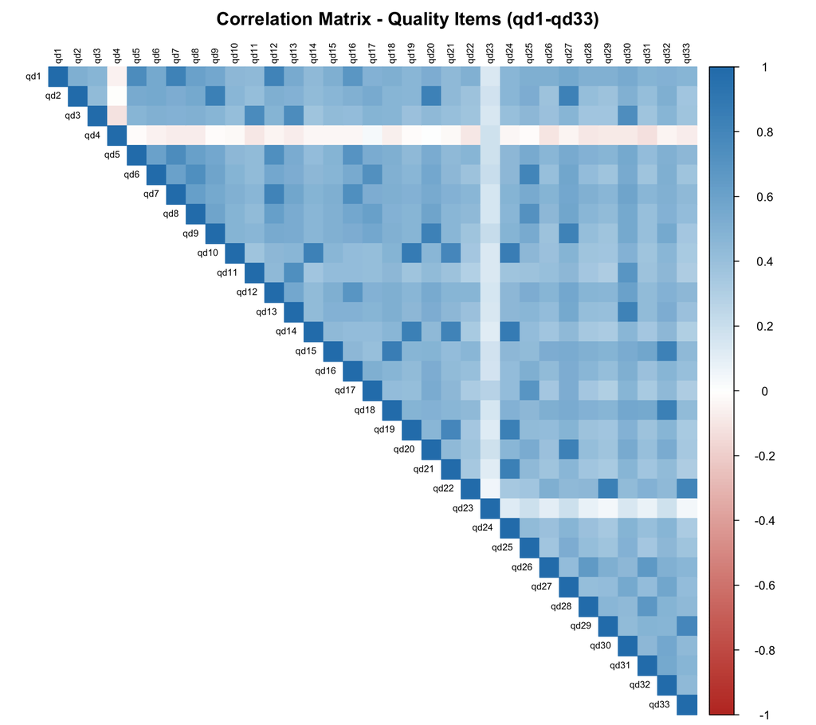

```r
# Correlation matrix calculation
cor_mat <- cor(quality_data_complete)

corrplot(cor_mat, method = "color", type = "upper", tl.cex = 0.62, tl.col = "black",
         col = colorRampPalette(c("#c0392b", "white", "#2980b9"))(200),
         title = "Correlation Matrix - Quality Items (qd1-qd33)", mar = c(0,0,2,0))
```

```r
# Get the top 20 highest correlations between items
cor_long <- as.data.frame(as.table(cor_mat)) %>%
  setNames(c("Item_1", "Item_2", "r")) %>%
  filter(as.character(Item_1) < as.character(Item_2)) %>%
  mutate(abs_r = abs(r)) %>%
  arrange(desc(abs_r))

head(cor_long, 20) %>%
  kbl(digits = 3, caption = "Top 20 pairwise correlations") %>%
  kable_styling(bootstrap_options = c("striped", "hover"), full_width = FALSE)
```

Top 20 pairwise correlations

| Item_1 | Item_2 | r | abs_r |
| --- | --- | --- | --- |
| qd10 | qd19 | 0.879 | 0.879 |
| qd14 | qd24 | 0.875 | 0.875 |
| qd15 | qd18 | 0.857 | 0.857 |
| qd10 | qd24 | 0.854 | 0.854 |
| qd19 | qd24 | 0.844 | 0.844 |
| qd22 | qd29 | 0.843 | 0.843 |
| qd14 | qd19 | 0.842 | 0.842 |
| qd21 | qd24 | 0.841 | 0.841 |
| qd2 | qd9 | 0.840 | 0.840 |
| qd18 | qd32 | 0.840 | 0.840 |
| qd2 | qd20 | 0.839 | 0.839 |
| qd15 | qd32 | 0.838 | 0.838 |
| qd20 | qd27 | 0.836 | 0.836 |
| qd2 | qd27 | 0.835 | 0.835 |
| qd20 | qd9 | 0.831 | 0.831 |
| qd10 | qd14 | 0.830 | 0.830 |
| qd27 | qd9 | 0.830 | 0.830 |
| qd13 | qd30 | 0.824 | 0.824 |
| qd1 | qd7 | 0.820 | 0.820 |
| qd14 | qd21 | 0.819 | 0.819 |

The correlation matrix shows a pattern of moderate to high positive correlations between the items (shown in blue), with the values of the top 20 highest correlations values situated between 0.879 and 0.819. This suggests the existence of common latent factors.

### 2.1.2 - KMO and Bartlett’s Test

Before running factor analysis, we also calculate the KMO (Kaiser-Meyer-Olkin), which checks if variables share enough common variance, and perform the Bartlett’s test, to see if the correlation matrix is an identity matrix or not.

```r
# calculate overall KMO and Bartlett's test
kmo_result      <- KMO(cor_mat)
bartlett_result <- cortest.bartlett(cor_mat, n = nrow(quality_data_complete))

cat("Overall KMO:", round(kmo_result$MSA, 3), "\n")
```

```
## Overall KMO: 0.962
```

```r
cat("Bartlett chi-square:", round(bartlett_result$chisq, 2),
    "| df:", bartlett_result$df,
    "| p-value:", bartlett_result$p.value, "\n")
```

```
## Bartlett chi-square: 29710.79 | df: 528 | p-value: 0
```

The overall KMO of **0.96** indicates excellent sampling adequacy. Bartlett’s test is highly significant (p < .001), confirming the correlation matrix is sufficiently different from an identity matrix. Both criteria support proceeding with factor analysis.

### 2.1.3 - Anti-Image Correlation Matrix

In addition to the overall KMO result and the Bartlett’s test, we can also have a look at the anti-image correlation matrix, which provides item-level evidence of factorability. The diagonal elements are the individual KMO (MSA) values for each item. Off-diagonal elements should be small in magnitude. This indicates that partial correlations between items are negligible once shared factor variance is removed.

```r
# print items with lowest MSA  using the previous calculate kmo
msa_df <- data.frame(
  Item = names(kmo_result$MSAi),
  MSA  = round(kmo_result$MSAi, 3)
) %>%
  mutate(
    Rating = case_when(
      MSA >= 0.90 ~ "Excellent",
      MSA >= 0.80 ~ "Good",
      MSA >= 0.70 ~ "Acceptable",
      MSA >= 0.60 ~ "Mediocre",
      TRUE        ~ "Unacceptable"
    )
  ) %>%
  arrange(MSA)  # lowest MSA first

msa_df %>%
  kbl(caption = "Item-level KMO (MSA) (lowest first)",
      col.names = c("Item", "MSA", "Rating")) %>%
  kable_styling(bootstrap_options = c("striped", "hover"), full_width = FALSE) %>%
  column_spec(2, bold = TRUE,
              color = ifelse(msa_df$MSA >= 0.70, "#27ae60", "#c0392b"))
```

Item-level KMO (MSA) (lowest first)

|  | Item | MSA | Rating |
| --- | --- | --- | --- |
| qd4 | qd4 | 0.654 | Mediocre |
| qd23 | qd23 | 0.905 | Excellent |
| qd22 | qd22 | 0.929 | Excellent |
| qd29 | qd29 | 0.935 | Excellent |
| qd15 | qd15 | 0.947 | Excellent |
| qd18 | qd18 | 0.952 | Excellent |
| qd33 | qd33 | 0.952 | Excellent |
| qd11 | qd11 | 0.954 | Excellent |
| qd3 | qd3 | 0.957 | Excellent |
| qd6 | qd6 | 0.957 | Excellent |
| qd24 | qd24 | 0.957 | Excellent |
| qd25 | qd25 | 0.957 | Excellent |
| qd10 | qd10 | 0.959 | Excellent |
| qd19 | qd19 | 0.959 | Excellent |
| qd31 | qd31 | 0.959 | Excellent |
| qd14 | qd14 | 0.960 | Excellent |
| qd13 | qd13 | 0.961 | Excellent |
| qd28 | qd28 | 0.962 | Excellent |
| qd2 | qd2 | 0.963 | Excellent |
| qd30 | qd30 | 0.964 | Excellent |
| qd32 | qd32 | 0.964 | Excellent |
| qd1 | qd1 | 0.966 | Excellent |
| qd20 | qd20 | 0.966 | Excellent |
| qd27 | qd27 | 0.966 | Excellent |
| qd26 | qd26 | 0.967 | Excellent |
| qd12 | qd12 | 0.969 | Excellent |
| qd7 | qd7 | 0.970 | Excellent |
| qd9 | qd9 | 0.970 | Excellent |
| qd17 | qd17 | 0.970 | Excellent |
| qd21 | qd21 | 0.974 | Excellent |
| qd5 | qd5 | 0.979 | Excellent |
| qd8 | qd8 | 0.982 | Excellent |
| qd16 | qd16 | 0.982 | Excellent |

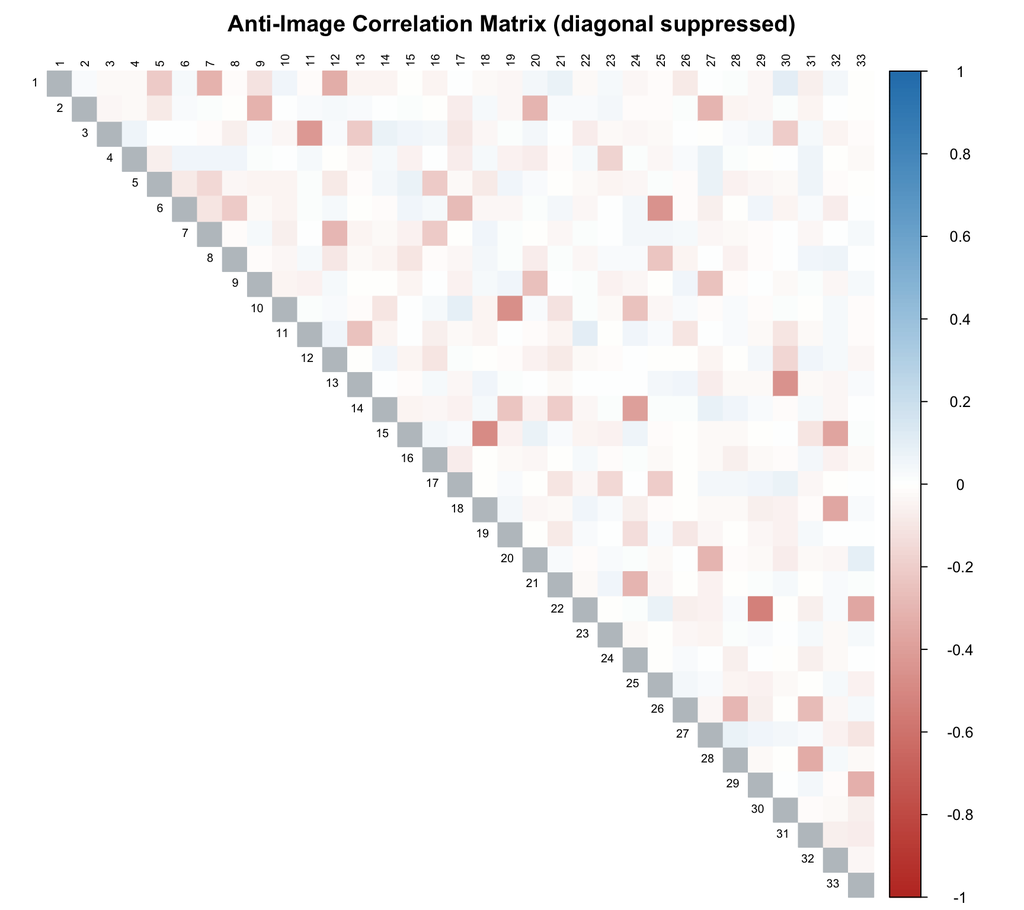

```r
# heatmap of the anti-image correlation matrix (diagonal suppressed for clarity)
# low values are preferable
anti_image_plot <- kmo_result$ImC
diag(anti_image_plot) <- NA

corrplot(anti_image_plot,
         method       = "color",
         type         = "upper",
         tl.cex       = 0.62,
         tl.col       = "black",
         na.label     = "square",
         na.label.col = "#bdc3c7",
         col          = colorRampPalette(c("#c0392b", "white", "#2980b9"))(200),
         title        = "Anti-Image Correlation Matrix (diagonal suppressed)",
         mar          = c(0, 0, 2, 0))
```

The majority of off-diagonal anti-image correlations are close to zero, confirming that partial correlations are negligible and items share enough common variance. The single item with the lowest MSA is qd4 (0.65, mediocre), which we should monitor.

## 2.2 - Number of Factors Assessment

### 2.2.1 - Initial Assessment

We have determined that the data is suitable for factor analysis. The next step is to decide on the number of factors we need. Three criteria will be used to determine this number: The Kaiser rule (eigenvalues greater than 1), a scree plot, and parallel analysis.

```r
# Calculation of the eigenvalues
eigen_values <- eigen(cor_mat)$values

# create a datable with the 12 highest eigenvalues, their value and cumulative variance
data.frame(Factor = 1:12,
           Eigenvalue = round(eigen_values[1:12], 3),
           Cum_Percentage = round(cumsum(eigen_values[1:12]) / sum(eigen_values) * 100, 1)) %>%
  kbl(caption = "Eigenvalues (first 12 factors)") %>%
  kable_styling(bootstrap_options = c("striped", "hover"), full_width = FALSE) %>%
  row_spec(which(eigen_values[1:12] >= 1), bold = TRUE, background = "#ebf5fb")
```

Eigenvalues (first 12 factors)

| Factor | Eigenvalue | Cum_Percentage |
| --- | --- | --- |
| 1 | 15.938 | 48.3 |
| 2 | 2.335 | 55.4 |
| 3 | 2.042 | 61.6 |
| 4 | 1.498 | 66.1 |
| 5 | 1.389 | 70.3 |
| 6 | 1.182 | 73.9 |
| 7 | 1.089 | 77.2 |
| 8 | 1.009 | 80.2 |
| 9 | 0.851 | 82.8 |
| 10 | 0.759 | 85.1 |
| 11 | 0.405 | 86.4 |
| 12 | 0.363 | 87.5 |

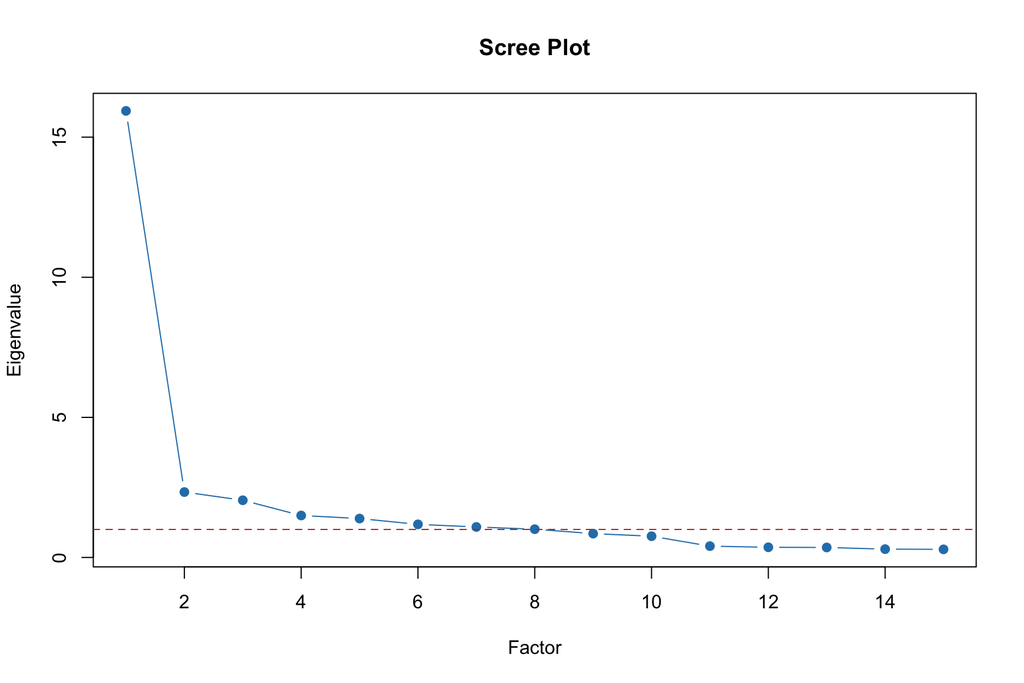

```r
# screeplot
plot(eigen_values[1:15], type = "b", pch = 19, col = "#2980b9",
     main = "Scree Plot", xlab = "Factor", ylab = "Eigenvalue")
abline(h = 1, col = "#c0392b", lty = 2)
```

With the screeplot alone, it is difficult to determine where the “elbow” is. Using the Kaiser criterion (eigenvalue above 1, red dotted line), we see where the limit would be.

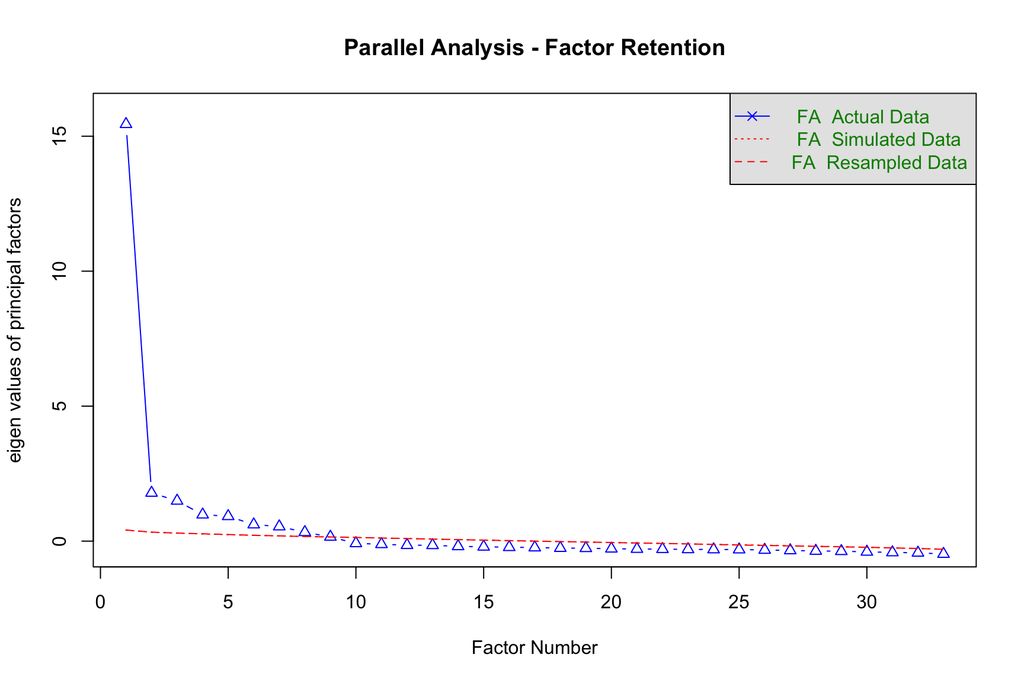

```
## Parallel analysis suggests that the number of factors =  8  and the number of components =  NA
```

```r
# run parallel analysis
fa.parallel(quality_data_complete, fa = "fa", fm = "pa",
            main = "Parallel Analysis - Factor Retention")
```

### 2.2.2 - Comparison of possible solutions

As stated previously, we try out 3 different solutions : 7, 8 and 9-factor solutions using $varimax$ method (orthogonal factor analysis).

```r
fa_7 <- fa(quality_data_complete, nfactors = 7, fm = "pa", rotate = "varimax")
fa_8 <- fa(quality_data_complete, nfactors = 8, fm = "pa", rotate = "varimax")
fa_9 <- fa(quality_data_complete, nfactors = 9, fm = "pa", rotate = "varimax")

cat("=== 7-Factor Solution ===\n"); print(fa_7, cut = 0.30, sort = TRUE)
```

```
## === 7-Factor Solution ===
```

```
## Factor Analysis using method =  pa
## Call: fa(r = quality_data_complete, nfactors = 7, rotate = "varimax",
##     fm = "pa")
## Standardized loadings (pattern matrix) based upon correlation matrix
##      item  PA2   PA1  PA5   PA3   PA6  PA7   PA4    h2   u2 com
## qd24   24 0.86                                   0.882 0.12 1.4
## qd14   14 0.85                                   0.850 0.15 1.4
## qd10   10 0.83                                   0.845 0.16 1.5
## qd19   19 0.83                                   0.842 0.16 1.5
## qd21   21 0.79                                   0.776 0.22 1.5
## qd7     7       0.74                             0.833 0.17 2.2
## qd1     1       0.73                             0.808 0.19 2.2
## qd12   12       0.71                             0.778 0.22 2.3
## qd5     5       0.64                  0.31       0.718 0.28 2.8
## qd16   16       0.61                             0.637 0.36 2.6
## qd2     2            0.78                        0.843 0.16 1.8
## qd20   20            0.76                        0.833 0.17 2.0
## qd9     9            0.74                        0.836 0.16 2.2
## qd27   27            0.74                        0.837 0.16 2.2
## qd22   22                  0.84                  0.837 0.16 1.4
## qd29   29                  0.81                  0.806 0.19 1.5
## qd33   33                  0.78                  0.741 0.26 1.5
## qd4     4                                        0.031 0.97 2.8
## qd15   15                        0.77            0.826 0.17 1.9
## qd18   18                        0.75            0.812 0.19 2.1
## qd32   32                        0.73            0.798 0.20 2.2
## qd31   31                  0.38  0.50            0.536 0.46 3.3
## qd26   26                  0.39  0.41            0.509 0.49 4.1
## qd28   28       0.33       0.35  0.40            0.481 0.52 4.2
## qd25   25                             0.75       0.779 0.22 1.8
## qd6     6                             0.74       0.823 0.18 2.1
## qd17   17                             0.63       0.644 0.36 2.4
## qd8     8       0.35                  0.56       0.676 0.32 3.7
## qd23   23                                        0.084 0.92 3.2
## qd3     3                                   0.76 0.775 0.22 1.8
## qd11   11                                   0.74 0.711 0.29 1.7
## qd13   13                                   0.73 0.800 0.20 2.2
## qd30   30                                   0.67 0.771 0.23 2.8
##
##                        PA2  PA1  PA5  PA3  PA6  PA7  PA4
```

[output cut: 16 more lines]

```
## The total n.obs was  933  with Likelihood Chi Square =  1251.01  with prob <  1e-110
##
## Tucker Lewis Index of factoring reliability =  0.947
## RMSEA index =  0.056  and the 90 % confidence intervals are  0.053 0.059
## BIC =  -923.6
## Fit based upon off diagonal values = 1
## Measures of factor score adequacy
##                                                    PA2  PA1  PA5  PA3  PA6  PA7
## Correlation of (regression) scores with factors   0.97 0.92 0.94 0.94 0.93 0.91
## Multiple R square of scores with factors          0.94 0.85 0.89 0.89 0.86 0.82
## Minimum correlation of possible factor scores     0.88 0.71 0.78 0.77 0.71 0.65
##                                                    PA4
## Correlation of (regression) scores with factors   0.93
## Multiple R square of scores with factors          0.86
## Minimum correlation of possible factor scores     0.72
```

```r
cat("\n=== 8-Factor Solution ===\n"); print(fa_8, cut = 0.30, sort = TRUE)
```

```
##
## === 8-Factor Solution ===
```

```
## Factor Analysis using method =  pa
## Call: fa(r = quality_data_complete, nfactors = 8, rotate = "varimax",
##     fm = "pa")
## Standardized loadings (pattern matrix) based upon correlation matrix
##      item  PA2  PA1  PA5   PA4  PA7   PA3  PA6   PA8    h2   u2 com
## qd24   24 0.86                                       0.883 0.12 1.4
## qd14   14 0.85                                       0.851 0.15 1.4
## qd10   10 0.83                                       0.845 0.15 1.5
## qd19   19 0.83                                       0.842 0.16 1.5
## qd21   21 0.79                                       0.776 0.22 1.5
## qd7     7      0.74                                  0.836 0.16 2.2
## qd1     1      0.73                                  0.807 0.19 2.2
## qd12   12      0.72                                  0.791 0.21 2.3
## qd5     5      0.64                                  0.723 0.28 2.8
## qd16   16      0.62                                  0.638 0.36 2.6
## qd2     2           0.79                             0.850 0.15 1.8
## qd20   20           0.76                             0.834 0.17 2.0
## qd9     9           0.74                             0.835 0.16 2.2
## qd27   27           0.74                             0.837 0.16 2.2
## qd3     3                 0.76                       0.775 0.23 1.8
## qd11   11                 0.74                       0.715 0.29 1.7
## qd13   13                 0.73                       0.801 0.20 2.2
## qd30   30                 0.67                       0.773 0.23 2.8
## qd25   25                      0.76                  0.786 0.21 1.9
## qd6     6                      0.74                  0.825 0.17 2.2
## qd17   17                      0.63                  0.643 0.36 2.5
## qd8     8      0.34            0.56                  0.678 0.32 3.8
## qd23   23                                            0.088 0.91 3.9
## qd22   22                            0.82            0.853 0.15 1.6
## qd29   29                            0.80            0.830 0.17 1.6
## qd33   33                            0.76            0.754 0.25 1.6
## qd15   15                                 0.77       0.864 0.14 2.1
## qd18   18                                 0.74       0.849 0.15 2.3
## qd32   32                                 0.72       0.831 0.17 2.4
## qd31   31                                 0.31  0.66 0.704 0.30 2.4
## qd28   28                                       0.66 0.681 0.32 2.3
## qd26   26                                       0.61 0.640 0.36 2.7
## qd4     4                                            0.043 0.96 2.4
##
##                        PA2  PA1  PA5  PA4  PA7  PA3  PA6  PA8
```

[output cut: 16 more lines]

```
## The total n.obs was  933  with Likelihood Chi Square =  661.63  with prob <  1e-30
##
## Tucker Lewis Index of factoring reliability =  0.977
## RMSEA index =  0.037  and the 90 % confidence intervals are  0.033 0.041
## BIC =  -1335.19
## Fit based upon off diagonal values = 1
## Measures of factor score adequacy
##                                                    PA2  PA1  PA5  PA4  PA7  PA3
## Correlation of (regression) scores with factors   0.97 0.92 0.95 0.93 0.91 0.94
## Multiple R square of scores with factors          0.94 0.85 0.90 0.86 0.83 0.88
## Minimum correlation of possible factor scores     0.88 0.71 0.79 0.72 0.66 0.76
##                                                    PA6  PA8
## Correlation of (regression) scores with factors   0.93 0.85
## Multiple R square of scores with factors          0.87 0.72
## Minimum correlation of possible factor scores     0.75 0.45
```

```r
cat("\n=== 9-Factor Solution ===\n"); print(fa_9, cut = 0.30, sort = TRUE)
```

```
##
## === 9-Factor Solution ===
```

```
## Factor Analysis using method =  pa
## Call: fa(r = quality_data_complete, nfactors = 9, rotate = "varimax",
##     fm = "pa")
## Standardized loadings (pattern matrix) based upon correlation matrix
##      item  PA2   PA1  PA5   PA4   PA3   PA7   PA6   PA8   PA9   h2   u2 com
## qd24   24 0.86                                                0.88 0.12 1.4
## qd14   14 0.85                                                0.85 0.15 1.4
## qd10   10 0.83                                                0.85 0.15 1.5
## qd19   19 0.83                                                0.84 0.16 1.5
## qd21   21 0.79                                                0.78 0.22 1.5
## qd7     7       0.75                                          0.84 0.16 2.2
## qd1     1       0.73                                          0.81 0.19 2.2
## qd12   12       0.72                                          0.79 0.21 2.2
## qd5     5       0.65                                          0.73 0.27 2.8
## qd16   16       0.62                                          0.64 0.36 2.6
## qd2     2            0.79                                     0.85 0.15 1.8
## qd20   20            0.77                                     0.83 0.17 2.0
## qd27   27            0.75                                     0.84 0.16 2.2
## qd9     9            0.74                                     0.83 0.17 2.2
## qd3     3                  0.77                               0.77 0.23 1.7
## qd11   11                  0.75                               0.72 0.28 1.6
## qd13   13                  0.74                               0.80 0.20 2.1
## qd30   30                  0.68                               0.77 0.23 2.6
## qd22   22                        0.83                         0.86 0.14 1.5
## qd29   29                        0.81                         0.83 0.17 1.6
## qd33   33                        0.77                         0.75 0.25 1.6
## qd25   25                              0.74                   0.78 0.22 2.0
## qd6     6                              0.73                   0.84 0.16 2.3
## qd17   17                              0.59                   0.67 0.33 3.3
## qd8     8       0.36                   0.55                   0.69 0.31 4.0
## qd15   15                                    0.75             0.86 0.14 2.2
## qd18   18                                    0.74             0.86 0.14 2.3
## qd32   32                                    0.71             0.83 0.17 2.5
## qd28   28                                          0.66       0.68 0.32 2.3
## qd31   31                                          0.65       0.70 0.30 2.5
## qd26   26                                          0.61       0.65 0.35 2.7
## qd23   23                                                0.47 0.27 0.73 1.5
## qd4     4                                                0.42 0.19 0.81 1.2
##
##                        PA2  PA1  PA5  PA4  PA3  PA7  PA6  PA8  PA9
```

[output cut: 16 more lines]

```
## The total n.obs was  933  with Likelihood Chi Square =  569.28  with prob <  5.4e-24
##
## Tucker Lewis Index of factoring reliability =  0.979
## RMSEA index =  0.035  and the 90 % confidence intervals are  0.031 0.039
## BIC =  -1256.57
## Fit based upon off diagonal values = 1
## Measures of factor score adequacy
##                                                    PA2  PA1  PA5  PA4  PA3  PA7
## Correlation of (regression) scores with factors   0.97 0.93 0.95 0.93 0.94 0.91
## Multiple R square of scores with factors          0.94 0.86 0.89 0.86 0.88 0.83
## Minimum correlation of possible factor scores     0.88 0.71 0.79 0.72 0.77 0.65
##                                                    PA6  PA8   PA9
## Correlation of (regression) scores with factors   0.93 0.85  0.64
## Multiple R square of scores with factors          0.87 0.72  0.42
## Minimum correlation of possible factor scores     0.73 0.44 -0.17
```

### 2.2.3 - Fit Comparison

We then compare the 3 fits against each other.

```r
# fit comparison
data.frame(
  Solution = c("7 Factors", "8 Factors", "9 Factors"),
  RMSEA    = round(c(fa_7$RMSEA[1], fa_8$RMSEA[1], fa_9$RMSEA[1]), 3),
  TLI      = round(c(fa_7$TLI,      fa_8$TLI,      fa_9$TLI),      3),
  BIC      = round(c(fa_7$BIC,      fa_8$BIC,      fa_9$BIC),      1),
  Var_Pct  = round(c(sum(fa_7$Vaccounted[2,]),
                     sum(fa_8$Vaccounted[2,]),
                     sum(fa_9$Vaccounted[2,])) * 100, 1)
) %>%
  kbl(caption = "Fit indices: 7-, 8-, and 9-factor solutions",
      col.names = c("Solution", "RMSEA", "TLI", "BIC", "Variance Explained (%)")) %>%
  kable_styling(bootstrap_options = c("striped", "hover"), full_width = FALSE) %>%
  row_spec(2, bold = TRUE, background = "#eafaf1")
```

Fit indices: 7-, 8-, and 9-factor solutions

| Solution | RMSEA | TLI | BIC | Variance Explained (%) |
| --- | --- | --- | --- | --- |
| 7 Factors | 0.056 | 0.947 | -923.6 | 72.0 |
| 8 Factors | 0.037 | 0.977 | -1335.2 | 74.2 |
| 9 Factors | 0.035 | 0.979 | -1256.6 | 75.4 |

The **7-factor** solution merges two factors into one factor, causing cross-loadings and reducing interpretability. The **9-factor solution** only has a marginal fit improvement, but the ninth factor is defined almost entirely by qd4 and qd23. In addition, their loadings are not very high (approx. equal to 0.4), and we saw previously that qd4 is an item to be monitored. This suggests overfactoring. The **8-factor solution** provides the best balance of fit, parsimony, and interpretability, with good loading values (above 0.6 for most of them). Only the items qd23 and qd4 have no important loading value, and qd8 has a loading at the limit of 0.6 (equal to 0.56) for one factor, and a cross-loading value of 0.34 for another factor. For all those reason, we will continue with the 8-factor analysis in the next parts of this analysis.

### 2.2.4 - Item Refinement

In the previous section, we have determined the number of factors. It is now time to refine the solution by trying to remove some items.

We have previously identified items qd4 and qd23 which do not have important loading values with the 8-factor solution. We therefore try to remove them and recalculate the factor analysis. We also observed that qd8 has an non-negligible cross-loading, and therefore try an additional solution in which this item is also removed. Finally, qd31 also has a cross-loading (but its loading is slightly more important, >0.6). We try a final solution without this item too.

```r
# Scenario 1: Remove qd4 and qd23
quality_data_r1 <- quality_data_complete %>% select(-qd4, -qd23)
fa_r1 <- fa(quality_data_r1, nfactors = 8, fm = "pa", rotate = "varimax")
print(fa_r1, cut = 0.30, sort = TRUE)
```

```
## Factor Analysis using method =  pa
## Call: fa(r = quality_data_r1, nfactors = 8, rotate = "varimax", fm = "pa")
## Standardized loadings (pattern matrix) based upon correlation matrix
##      item  PA2  PA1  PA5  PA4  PA3  PA7  PA6  PA8   h2   u2 com
## qd24   22 0.86                                    0.88 0.12 1.4
## qd14   13 0.85                                    0.85 0.15 1.4
## qd10    9 0.83                                    0.85 0.15 1.5
## qd19   18 0.83                                    0.84 0.16 1.5
## qd21   20 0.79                                    0.78 0.22 1.5
## qd7     6      0.74                               0.84 0.16 2.2
## qd1     1      0.72                               0.81 0.19 2.3
## qd12   11      0.72                               0.79 0.21 2.3
## qd5     4      0.64                               0.72 0.28 2.8
## qd16   15      0.62                               0.64 0.36 2.6
## qd2     2           0.79                          0.85 0.15 1.8
## qd20   19           0.77                          0.83 0.17 1.9
## qd9     8           0.75                          0.83 0.17 2.1
## qd27   25           0.75                          0.84 0.16 2.2
## qd3     3                0.77                     0.77 0.23 1.7
## qd11   10                0.75                     0.71 0.29 1.6
## qd13   12                0.74                     0.80 0.20 2.1
## qd30   28                0.68                     0.77 0.23 2.6
## qd22   21                     0.83                0.86 0.14 1.5
## qd29   27                     0.81                0.83 0.17 1.6
## qd33   31                     0.77                0.75 0.25 1.6
## qd25   23                          0.75           0.79 0.21 1.9
## qd6     5                          0.73           0.84 0.16 2.3
## qd17   16                          0.59           0.62 0.38 2.8
## qd8     7      0.35                0.55           0.68 0.32 4.0
## qd15   14                               0.75      0.86 0.14 2.2
## qd18   17                               0.74      0.86 0.14 2.3
## qd32   30                               0.72      0.83 0.17 2.5
## qd28   26                                    0.67 0.69 0.31 2.2
## qd31   29                                    0.66 0.70 0.30 2.4
## qd26   24                                    0.62 0.65 0.35 2.7
##
##                        PA2  PA1  PA5  PA4  PA3  PA7  PA6  PA8
## SS loadings           4.58 3.60 3.39 3.15 2.76 2.61 2.34 1.93
## Proportion Var        0.15 0.12 0.11 0.10 0.09 0.08 0.08 0.06
## Cumulative Var        0.15 0.26 0.37 0.47 0.56 0.65 0.72 0.79
```

[output cut: 13 more lines]

```
## The total n.obs was  933  with Likelihood Chi Square =  546.41  with prob <  4.8e-25
##
## Tucker Lewis Index of factoring reliability =  0.98
## RMSEA index =  0.036  and the 90 % confidence intervals are  0.032 0.04
## BIC =  -1129
## Fit based upon off diagonal values = 1
## Measures of factor score adequacy
##                                                    PA2  PA1  PA5  PA4  PA3  PA7
## Correlation of (regression) scores with factors   0.97 0.92 0.95 0.93 0.94 0.91
## Multiple R square of scores with factors          0.94 0.85 0.90 0.86 0.89 0.83
## Minimum correlation of possible factor scores     0.88 0.71 0.79 0.72 0.78 0.66
##                                                    PA6  PA8
## Correlation of (regression) scores with factors   0.93 0.85
## Multiple R square of scores with factors          0.87 0.72
## Minimum correlation of possible factor scores     0.74 0.45
```

```r
# Scenario 2: Additionally remove qd8
quality_data_final_ortho <- quality_data_complete %>% select(-qd4, -qd23, -qd8)
fa_final_ortho <- fa(quality_data_final_ortho, nfactors = 8, fm = "pa", rotate = "varimax")
print(fa_final_ortho, cut = 0.30, sort = TRUE)
```

```
## Factor Analysis using method =  pa
## Call: fa(r = quality_data_final_ortho, nfactors = 8, rotate = "varimax",
##     fm = "pa")
## Standardized loadings (pattern matrix) based upon correlation matrix
##      item  PA2  PA1  PA5  PA4  PA3  PA6  PA7  PA8   h2   u2 com
## qd24   21 0.86                                    0.88 0.12 1.4
## qd14   12 0.85                                    0.85 0.15 1.4
## qd10    8 0.83                                    0.85 0.15 1.5
## qd19   17 0.83                                    0.84 0.16 1.5
## qd21   19 0.79                                    0.78 0.22 1.5
## qd7     6      0.75                               0.84 0.16 2.2
## qd1     1      0.73                               0.81 0.19 2.2
## qd12   10      0.72                               0.79 0.21 2.2
## qd5     4      0.65                               0.72 0.28 2.7
## qd16   14      0.62                               0.64 0.36 2.6
## qd2     2           0.80                          0.85 0.15 1.8
## qd20   18           0.77                          0.83 0.17 1.9
## qd9     7           0.75                          0.83 0.17 2.1
## qd27   24           0.75                          0.84 0.16 2.1
## qd3     3                0.77                     0.77 0.23 1.7
## qd11    9                0.75                     0.71 0.29 1.6
## qd13   11                0.74                     0.80 0.20 2.0
## qd30   27                0.68                     0.77 0.23 2.6
## qd22   20                     0.83                0.86 0.14 1.5
## qd29   26                     0.81                0.83 0.17 1.6
## qd33   30                     0.77                0.75 0.25 1.6
## qd15   13                          0.76           0.86 0.14 2.2
## qd18   16                          0.74           0.86 0.14 2.3
## qd32   29                          0.72           0.83 0.17 2.5
## qd25   22                               0.72      0.77 0.23 2.2
## qd6     5                               0.71      0.83 0.17 2.5
## qd17   15                               0.59      0.64 0.36 2.9
## qd28   25                                    0.67 0.68 0.32 2.2
## qd31   28                                    0.66 0.70 0.30 2.4
## qd26   23                                    0.62 0.65 0.35 2.6
##
##                        PA2  PA1  PA5  PA4  PA3  PA6  PA7  PA8
## SS loadings           4.55 3.58 3.39 3.13 2.74 2.33 2.02 1.92
## Proportion Var        0.15 0.12 0.11 0.10 0.09 0.08 0.07 0.06
## Cumulative Var        0.15 0.27 0.38 0.49 0.58 0.66 0.73 0.79
```

[output cut: 13 more lines]

```
## The total n.obs was  933  with Likelihood Chi Square =  510.78  with prob <  1.3e-24
##
## Tucker Lewis Index of factoring reliability =  0.98
## RMSEA index =  0.037  and the 90 % confidence intervals are  0.033 0.041
## BIC =  -1014.19
## Fit based upon off diagonal values = 1
## Measures of factor score adequacy
##                                                    PA2  PA1  PA5  PA4  PA3  PA6
## Correlation of (regression) scores with factors   0.97 0.93 0.95 0.93 0.94 0.93
## Multiple R square of scores with factors          0.94 0.86 0.90 0.86 0.89 0.87
## Minimum correlation of possible factor scores     0.88 0.71 0.80 0.72 0.78 0.74
##                                                    PA7  PA8
## Correlation of (regression) scores with factors   0.90 0.85
## Multiple R square of scores with factors          0.81 0.72
## Minimum correlation of possible factor scores     0.61 0.45
```

```r
# Scenario 3: Check effect of additionally removing qd31
quality_data_r3 <- quality_data_complete %>% select(-qd4, -qd23, -qd8, -qd31)
fa_r3 <- fa(quality_data_r3, nfactors = 8, fm = "pa", rotate = "varimax")
print(fa_r3, cut = 0.30, sort = TRUE)
```

```
## Factor Analysis using method =  pa
## Call: fa(r = quality_data_r3, nfactors = 8, rotate = "varimax", fm = "pa")
## Standardized loadings (pattern matrix) based upon correlation matrix
##      item  PA2  PA1  PA5  PA4  PA3  PA6  PA7  PA8   h2   u2 com
## qd24   21 0.86                                    0.88 0.12 1.4
## qd14   12 0.85                                    0.85 0.15 1.4
## qd10    8 0.83                                    0.84 0.16 1.5
## qd19   17 0.83                                    0.84 0.16 1.5
## qd21   19 0.79                                    0.78 0.22 1.5
## qd7     6      0.75                               0.84 0.16 2.1
## qd1     1      0.73                               0.81 0.19 2.2
## qd12   10      0.73                               0.79 0.21 2.2
## qd5     4      0.65                               0.72 0.28 2.7
## qd16   14      0.62                               0.64 0.36 2.5
## qd2     2           0.80                          0.85 0.15 1.8
## qd20   18           0.77                          0.83 0.17 1.9
## qd9     7           0.75                          0.83 0.17 2.1
## qd27   24           0.75                          0.84 0.16 2.1
## qd3     3                0.77                     0.77 0.23 1.7
## qd11    9                0.75                     0.72 0.28 1.6
## qd13   11                0.74                     0.81 0.19 2.0
## qd30   27                0.68                     0.77 0.23 2.5
## qd22   20                     0.84                0.86 0.14 1.4
## qd29   26                     0.82                0.83 0.17 1.5
## qd33   29                     0.78                0.75 0.25 1.5
## qd15   13                          0.77           0.86 0.14 2.0
## qd18   16                          0.76           0.86 0.14 2.1
## qd32   28                          0.73           0.83 0.17 2.3
## qd25   22                               0.72      0.77 0.23 2.2
## qd6     5                               0.71      0.83 0.17 2.5
## qd17   15                               0.60      0.64 0.36 2.9
## qd26   23                     0.31           0.61 0.69 0.31 3.0
## qd28   25                                    0.59 0.64 0.36 3.0
##
##                        PA2  PA1  PA5  PA4  PA3  PA6  PA7  PA8
## SS loadings           4.55 3.62 3.39 3.14 2.80 2.42 2.03 1.04
## Proportion Var        0.16 0.12 0.12 0.11 0.10 0.08 0.07 0.04
## Cumulative Var        0.16 0.28 0.40 0.51 0.60 0.69 0.76 0.79
## Proportion Explained  0.20 0.16 0.15 0.14 0.12 0.11 0.09 0.05
## Cumulative Proportion 0.20 0.36 0.50 0.64 0.76 0.87 0.95 1.00
```

[output cut: 11 more lines]

```
## The total n.obs was  933  with Likelihood Chi Square =  483.78  with prob <  3.7e-25
##
## Tucker Lewis Index of factoring reliability =  0.979
## RMSEA index =  0.039  and the 90 % confidence intervals are  0.034 0.043
## BIC =  -897.58
## Fit based upon off diagonal values = 1
## Measures of factor score adequacy
##                                                    PA2  PA1  PA5  PA4  PA3  PA6
## Correlation of (regression) scores with factors   0.97 0.93 0.95 0.93 0.94 0.94
## Multiple R square of scores with factors          0.94 0.86 0.90 0.86 0.89 0.88
## Minimum correlation of possible factor scores     0.88 0.71 0.80 0.72 0.78 0.76
##                                                    PA7  PA8
## Correlation of (regression) scores with factors   0.90 0.78
## Multiple R square of scores with factors          0.81 0.62
## Minimum correlation of possible factor scores     0.61 0.23
```

**Items removed and justification:**

- **qd4** (“my smartphone is really unique”): was removed due to a relatively low MSA (0.65) and the presence of cross-loadings across multiple factors, indicating a lack of clear association with a single latent dimension. This also makes its interpretation less stable.
- **qd8** (“extra features usually function”): was removed because it shows a relatively low primary loading and non-negligible cross-loadings across multiple factors, meaning it does not load clearly on a single factor and leads to ambiguous interpretation.
- **qd23** (“prestigious item”): was removed because it does not exhibit a strong and distinct loading on any single factor and appears to overlap conceptually with other items (e.g. qd4), suggesting redundancy rather than a unique dimension.
- **qd31 retained**: was retained despite minor cross-loadings, as it shows a sufficiently strong primary loading on the Durability factor and contributes meaningfully to its interpretation. Removing it would weaken the factor structure without improving overall clarity.

## 2.3 - Final Orthogonal Factor Analysis

### 2.3.1 - Loading Heatmap

The final solution has been determined (8 factors, items qd4, qd8 and qd23 removed). All items show unambiguous loading patterns on a single factor. No item has a primary loading below 0.40, and no meaningful cross-loadings above 0.30 are present in the final solution.

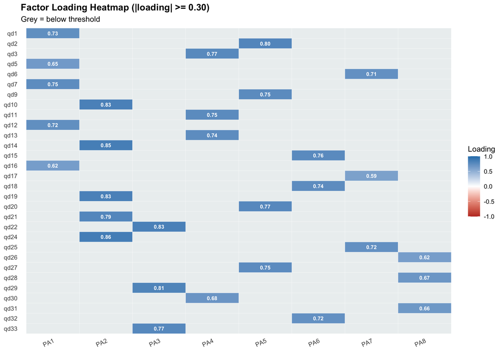

```r
factor_names <- colnames(fa_final_ortho$loadings)

# plot loading heatmap
loadings_df <- as.data.frame(unclass(fa_final_ortho$loadings)) %>%
  setNames(factor_names) %>%
  rownames_to_column("Item") %>%
  pivot_longer(-Item, names_to = "Factor", values_to = "Loading") %>%
  mutate(Loading_thresh = ifelse(abs(Loading) >= 0.30, Loading, NA),
         Item = factor(Item, levels = rev(unique(Item))))

ggplot(loadings_df, aes(x = Factor, y = Item, fill = Loading_thresh)) +
  geom_tile(colour = "white") +
  geom_text(aes(label = ifelse(!is.na(Loading_thresh),
                               sprintf("%.2f", Loading_thresh), "")),
            size = 2.7, colour = "white", fontface = "bold") +
  scale_fill_gradient2(low = "#c0392b", mid = "white", high = "#2980b9",
                       midpoint = 0, na.value = "#ecf0f1", limits = c(-1,1),
                       name = "Loading") +
  labs(title = "Factor Loading Heatmap (|loading| >= 0.30)",
       subtitle = "Grey = below threshold", x = NULL, y = NULL) +
  theme_minimal(base_size = 11) +
  theme(plot.title = element_text(face = "bold"), panel.grid = element_blank(),
        axis.text.x = element_text(angle = 25, hjust = 1))
```

### 2.3.2 - Factor naming table

Each item is assigned to the factor with the highest absolute loading. Factor labels are derived from the quality literature (Table 1 of the case study), using the text labels of each item, and deciding what those items best describe as an overall quality factor with the help of the previous calculated loading heatmap. They are saved in $factor_names$.

```r
# Item text labels
item_text <- c(
  qd1  = "Consistently performs",
  qd2  = "Overall attractiveness",
  qd3  = "User experience with functions",
  qd5  = "Performance is excellent",
  qd6  = "Innovativeness of extra features",
  qd7  = "Overall performance",
  qd9  = "Appeal of design",
  qd10 = "Competence of customer service staff",
  qd11 = "Learning to operate smartphone",
  qd12 = "Performs core functions well",
  qd13 = "Ease of use",
  qd14 = "Promptness of customer service",
  qd15 = "Endurance of materials",
  qd16 = "Functioning speed",
  qd17 = "Excitement from extra features",
  qd18 = "Robustness of materials",
  qd19 = "Professionalism of service staff",
  qd20 = "Look and feel",
  qd21 = "Accessibility of customer service",
  qd22 = "Severity of defects/glitches",
  qd24 = "Responsiveness of customer service",
  qd25 = "Number of additional features",
  qd26 = "Time span without major defects",
  qd27 = "Overall fit and finish",
  qd28 = "Works under heavy usage",
  qd29 = "Frequency of defects/glitches",
  qd30 = "Usability",
  qd31 = "Life span",
  qd32 = "Standard of materials used",
  qd33 = "Probability of failure/malfunction"
)

# Factor names
factor_names <- c("Serviceability", "Performance", "Aesthetics", "Ease of Use",
                  "Reliability", "Material Quality", "Features", "Durability")

# factor naming table
# extract loadings, assign factor names, and map item text labels
loadings_raw        <- as.data.frame(unclass(fa_final_ortho$loadings))
colnames(loadings_raw) <- factor_names
item_ids            <- tolower(rownames(loadings_raw))  # ensure lowercase

# build table => assign each item to its highest-loading factor
naming_table <- data.frame(
  Item            = item_ids,
  Item_Text       = item_text[item_ids],
  Primary_Factor  = factor_names[apply(loadings_raw, 1, function(x) which.max(abs(x)))],
  Primary_Loading = apply(loadings_raw, 1, function(x) round(max(abs(x)), 2)),
  stringsAsFactors = FALSE
) %>%
  arrange(Primary_Factor, desc(Primary_Loading))

# display table grouped by factor using pack_rows()
naming_table %>%
  kbl(col.names = c("Item", "Item Content", "Factor", "Loading"),
      caption = "Factor Naming Table") %>%
  kable_styling(bootstrap_options = c("striped", "hover", "condensed"), full_width = TRUE) %>%
  column_spec(4, bold = TRUE, color = "#2980b9") %>%
  { tbl <- .
    factors <- unique(naming_table$Primary_Factor)
    for (f in factors) {
      idx <- which(naming_table$Primary_Factor == f)
      tbl <- pack_rows(tbl, f, min(idx), max(idx))
    }
    tbl
  }
```

Factor Naming Table

|  | Item | Item Content | Factor | Loading |
| --- | --- | --- | --- | --- |
| **Aesthetics** |  |  |  |  |
| qd2 | qd2 | Overall attractiveness | Aesthetics | 0.80 |
| qd20 | qd20 | Look and feel | Aesthetics | 0.77 |
| qd9 | qd9 | Appeal of design | Aesthetics | 0.75 |
| qd27 | qd27 | Overall fit and finish | Aesthetics | 0.75 |
| **Durability** |  |  |  |  |
| qd28 | qd28 | Works under heavy usage | Durability | 0.67 |
| qd31 | qd31 | Life span | Durability | 0.66 |
| qd26 | qd26 | Time span without major defects | Durability | 0.62 |
| **Ease of Use** |  |  |  |  |
| qd3 | qd3 | User experience with functions | Ease of Use | 0.77 |
| qd11 | qd11 | Learning to operate smartphone | Ease of Use | 0.75 |
| qd13 | qd13 | Ease of use | Ease of Use | 0.74 |
| qd30 | qd30 | Usability | Ease of Use | 0.68 |
| **Features** |  |  |  |  |
| qd25 | qd25 | Number of additional features | Features | 0.72 |
| qd6 | qd6 | Innovativeness of extra features | Features | 0.71 |
| qd17 | qd17 | Excitement from extra features | Features | 0.59 |
| **Material Quality** |  |  |  |  |
| qd15 | qd15 | Endurance of materials | Material Quality | 0.76 |
| qd18 | qd18 | Robustness of materials | Material Quality | 0.74 |
| qd32 | qd32 | Standard of materials used | Material Quality | 0.72 |
| **Performance** |  |  |  |  |
| qd7 | qd7 | Overall performance | Performance | 0.75 |
| qd1 | qd1 | Consistently performs | Performance | 0.73 |
| qd12 | qd12 | Performs core functions well | Performance | 0.72 |
| qd5 | qd5 | Performance is excellent | Performance | 0.65 |
| qd16 | qd16 | Functioning speed | Performance | 0.62 |
| **Reliability** |  |  |  |  |
| qd22 | qd22 | Severity of defects/glitches | Reliability | 0.83 |
| qd29 | qd29 | Frequency of defects/glitches | Reliability | 0.81 |
| qd33 | qd33 | Probability of failure/malfunction | Reliability | 0.77 |
| **Serviceability** |  |  |  |  |
| qd24 | qd24 | Responsiveness of customer service | Serviceability | 0.86 |
| qd14 | qd14 | Promptness of customer service | Serviceability | 0.85 |
| qd10 | qd10 | Competence of customer service staff | Serviceability | 0.83 |
| qd19 | qd19 | Professionalism of service staff | Serviceability | 0.83 |
| qd21 | qd21 | Accessibility of customer service | Serviceability | 0.79 |

### 2.3.3 - Communalities

Communalities calculation should also be performed when performing factor analysis. They indicate how much of each item’s variance is captured by the 8-factor solution. Values above 0.50 are considered good, while values below 0.40 suggest the item is poorly represented by the extracted factors. The uniqueness (given by u2 = 1 - h2) reflects the proportion of variance that remains unexplained.

```r
# calculate communalities table, sorted from highest to lowest h2
comm_df <- data.frame(
  Item      = names(fa_final_ortho$communality),
  Item_Text = item_text[names(fa_final_ortho$communality)],
  h2        = round(fa_final_ortho$communality, 3),
  u2        = round(fa_final_ortho$uniquenesses, 3),
  stringsAsFactors = FALSE
) %>% arrange(desc(h2))

# print table, and highlight items with h2 < 0.40
comm_df %>%
  kbl(col.names = c("Item", "Content", "Communality (h2)", "Uniqueness (u2)"),
      caption = "Communalities - Final 8-Factor Solution") %>%
  kable_styling(bootstrap_options = c("striped", "hover", "condensed"), full_width = TRUE) %>%
  row_spec(which(comm_df$h2 < 0.40), background = "#fef9e7")
```

Communalities - Final 8-Factor Solution

|  | Item | Content | Communality (h2) | Uniqueness (u2) |
| --- | --- | --- | --- | --- |
| qd24 | qd24 | Responsiveness of customer service | 0.883 | 0.117 |
| qd15 | qd15 | Endurance of materials | 0.860 | 0.140 |
| qd18 | qd18 | Robustness of materials | 0.857 | 0.143 |
| qd22 | qd22 | Severity of defects/glitches | 0.856 | 0.144 |
| qd2 | qd2 | Overall attractiveness | 0.851 | 0.149 |
| qd14 | qd14 | Promptness of customer service | 0.851 | 0.149 |
| qd10 | qd10 | Competence of customer service staff | 0.845 | 0.155 |
| qd19 | qd19 | Professionalism of service staff | 0.842 | 0.158 |
| qd27 | qd27 | Overall fit and finish | 0.839 | 0.161 |
| qd7 | qd7 | Overall performance | 0.838 | 0.162 |
| qd6 | qd6 | Innovativeness of extra features | 0.834 | 0.166 |
| qd9 | qd9 | Appeal of design | 0.834 | 0.166 |
| qd20 | qd20 | Look and feel | 0.834 | 0.166 |
| qd29 | qd29 | Frequency of defects/glitches | 0.830 | 0.170 |
| qd32 | qd32 | Standard of materials used | 0.830 | 0.170 |
| qd1 | qd1 | Consistently performs | 0.807 | 0.193 |
| qd13 | qd13 | Ease of use | 0.805 | 0.195 |
| qd12 | qd12 | Performs core functions well | 0.790 | 0.210 |
| qd21 | qd21 | Accessibility of customer service | 0.776 | 0.224 |
| qd30 | qd30 | Usability | 0.774 | 0.226 |
| qd25 | qd25 | Number of additional features | 0.772 | 0.228 |
| qd3 | qd3 | User experience with functions | 0.770 | 0.230 |
| qd33 | qd33 | Probability of failure/malfunction | 0.755 | 0.245 |
| qd5 | qd5 | Performance is excellent | 0.722 | 0.278 |
| qd11 | qd11 | Learning to operate smartphone | 0.714 | 0.286 |
| qd31 | qd31 | Life span | 0.699 | 0.301 |
| qd28 | qd28 | Works under heavy usage | 0.685 | 0.315 |
| qd26 | qd26 | Time span without major defects | 0.649 | 0.351 |
| qd17 | qd17 | Excitement from extra features | 0.641 | 0.359 |
| qd16 | qd16 | Functioning speed | 0.639 | 0.361 |

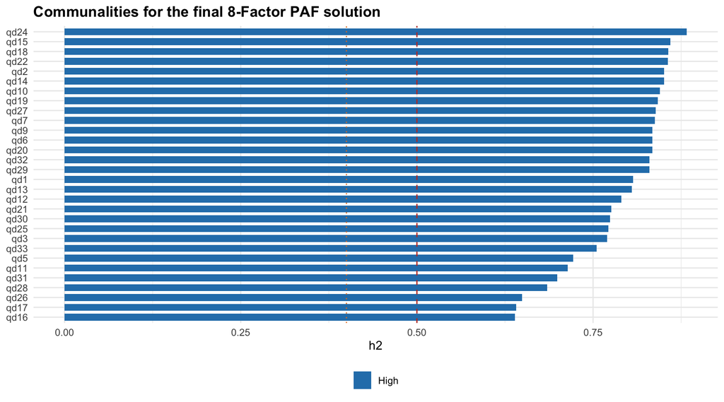

```r
#barchart of communalities
# blue = h2 >= 0.50 (good), light blue = h2 < 0.50 (moderate)
# red dashed line = 0.50 threshold, orange dotted = 0.40 minimum
ggplot(comm_df, aes(x = reorder(Item, h2), y = h2,
                    fill = ifelse(h2 >= 0.50, "High", "Moderate"))) +
  geom_col(width = 0.7) +
  geom_hline(yintercept = 0.50, linetype = "dashed", colour = "#c0392b") +
  geom_hline(yintercept = 0.40, linetype = "dotted", colour = "#e67e22") +
  scale_fill_manual(values = c("High" = "#2980b9", "Moderate" = "#aed6f1"), name = NULL) +
  coord_flip() +
  labs(title = "Communalities for the final 8-Factor PAF solution", x = NULL, y = "h2") +
  theme_minimal(base_size = 11) +
  theme(plot.title = element_text(face = "bold"), legend.position = "bottom")
```

### 2.3.4 - Cronbach’s Alpha per factor check

Cronbach’s alpha is computed for the final 8-factor solution. This gives us an additional consistency check for the assignement of the items to each factor.

```r
# item assignments for the final 8-factor solution
factor_items_8 <- list(
  "Serviceability" = c("qd10","qd14","qd19","qd21","qd24"),
  "Performance"      = c("qd1","qd5","qd7","qd12","qd16"),
  "Aesthetics"       = c("qd2","qd9","qd20","qd27"),
  "Ease of Use"      = c("qd3","qd11","qd13","qd30"),
  "Material Quality" = c("qd15","qd18","qd32"),
  "Reliability"      = c("qd22","qd29","qd33"),
  "Features"         = c("qd6","qd17","qd25"),
  "Durability"       = c("qd26","qd28","qd31")
)

# compute alpha for each factor
alpha_8 <- do.call(rbind, Filter(Negate(is.null),
  lapply(names(factor_items_8), function(f) {
    items_ok <- factor_items_8[[f]][factor_items_8[[f]] %in% names(quality_data_final_ortho)]
    if (length(items_ok) < 2) return(NULL)
    a <- psych::alpha(quality_data_final_ortho[, items_ok, drop = FALSE], warnings = FALSE)
    data.frame(
      Factor  = f,
      N_Items = length(items_ok),
      Alpha   = round(a$total$raw_alpha, 3),
      Rating  = case_when(
        a$total$raw_alpha >= 0.90 ~ "Excellent",
        a$total$raw_alpha >= 0.80 ~ "Good",
        a$total$raw_alpha >= 0.70 ~ "Acceptable",
        TRUE                      ~ "Questionable"
      ),
      stringsAsFactors = FALSE
    )
  })
))

# show table
alpha_8 %>%
  kbl(caption = "Cronbach's Alpha for the 8-Factor Solution",
      col.names = c("Factor", "N Items", "Alpha", "Rating")) %>%
  kable_styling(bootstrap_options = c("striped", "hover"), full_width = TRUE) %>%
  column_spec(3, bold = TRUE,
              color = ifelse(alpha_8$Alpha >= 0.70, "#27ae60", "#c0392b"))
```

Cronbach’s Alpha for the 8-Factor Solution

| Factor | N Items | Alpha | Rating |
| --- | --- | --- | --- |
| Serviceability | 5 | 0.962 | Excellent |
| Performance | 5 | 0.934 | Excellent |
| Aesthetics | 4 | 0.953 | Excellent |
| Ease of Use | 4 | 0.922 | Excellent |
| Material Quality | 3 | 0.942 | Excellent |
| Reliability | 3 | 0.928 | Excellent |
| Features | 3 | 0.895 | Good |
| Durability | 3 | 0.856 | Good |

From the above results, we indeed see that the chosen solution is a good choice, with Cronbach’s alpha values above 0.85 for all 8 factors.

## 2.4 - Principal Component Analysis (PCA)

A PCA with varimax rotation is run on the same 30-item set to verify whether the 8-factor structure is also robust to the choice of extraction method.

```r
# PCA calculation using the previously chosen 8 factor solution
pca_final <- principal(quality_data_final_ortho, nfactors = 8, rotate = "varimax")
print(pca_final, cut = 0.30, sort = TRUE)
```

```
## Principal Components Analysis
## Call: principal(r = quality_data_final_ortho, nfactors = 8, rotate = "varimax")
## Standardized loadings (pattern matrix) based upon correlation matrix
##      item  RC2  RC1  RC5  RC4  RC6  RC3  RC7  RC8   h2    u2 com
## qd14   12 0.87                                    0.88 0.120 1.3
## qd24   21 0.87                                    0.90 0.102 1.4
## qd10    8 0.85                                    0.87 0.125 1.4
## qd19   17 0.85                                    0.87 0.127 1.4
## qd21   19 0.83                                    0.83 0.170 1.5
## qd7     6      0.77                               0.86 0.144 2.1
## qd12   10      0.76                               0.83 0.171 2.0
## qd1     1      0.76                               0.84 0.163 2.1
## qd16   14      0.71                               0.73 0.272 2.0
## qd5     4      0.71                               0.78 0.221 2.3
## qd2     2           0.82                          0.89 0.111 1.7
## qd20   18           0.80                          0.88 0.122 1.8
## qd9     7           0.78                          0.87 0.126 2.0
## qd27   24           0.78                          0.88 0.123 2.0
## qd11    9                0.82                     0.82 0.184 1.4
## qd3     3                0.81                     0.84 0.164 1.6
## qd13   11                0.77                     0.84 0.160 2.0
## qd30   27                0.71                     0.81 0.186 2.4
## qd22   20                     0.85                0.89 0.110 1.5
## qd33   30                     0.84                0.85 0.146 1.5
## qd29   26                     0.84                0.88 0.121 1.5
## qd15   13                          0.79           0.90 0.096 2.0
## qd18   16                          0.78           0.90 0.099 2.1
## qd32   29                          0.77           0.89 0.111 2.2
## qd25   22                               0.78      0.85 0.151 1.9
## qd6     5      0.30                     0.74      0.86 0.143 2.3
## qd17   15                               0.73      0.78 0.219 2.1
## qd28   25                                    0.77 0.80 0.198 1.8
## qd31   28                                    0.74 0.79 0.209 2.0
## qd26   23                                    0.73 0.77 0.232 2.0
##
##                        RC2  RC1  RC5  RC4  RC6  RC3  RC7  RC8
## SS loadings           4.66 3.92 3.49 3.31 2.82 2.50 2.34 2.33
## Proportion Var        0.16 0.13 0.12 0.11 0.09 0.08 0.08 0.08
## Cumulative Var        0.16 0.29 0.40 0.51 0.61 0.69 0.77 0.85
## Proportion Explained  0.18 0.15 0.14 0.13 0.11 0.10 0.09 0.09
## Cumulative Proportion 0.18 0.34 0.48 0.61 0.72 0.82 0.91 1.00
##
## Mean item complexity =  1.8
## Test of the hypothesis that 8 components are sufficient.
##
## The root mean square of the residuals (RMSR) is  0.02
##  with the empirical chi square  321.19  with prob <  1.8e-05
##
## Fit based upon off diagonal values = 1
```

```r
# Put the eigenvalues of each method in a table for better comparison and display it
data.frame(
  Factor      = factor_names,
  PAF_Var_Pct = round(fa_final_ortho$Vaccounted[2,] * 100, 2),
  PCA_Var_Pct = round(pca_final$Vaccounted[2,]      * 100, 2),
  Difference  = round((pca_final$Vaccounted[2,] -
                       fa_final_ortho$Vaccounted[2,]) * 100, 2)
) %>%
  kbl(caption = "Variance explained: PAF vs PCA",
      col.names = c("Factor","PAF (%)","PCA (%)","Difference")) %>%
  kable_styling(bootstrap_options = c("striped", "hover"), full_width = FALSE)
```

Variance explained: PAF vs PCA

|  | Factor | PAF (%) | PCA (%) | Difference |
| --- | --- | --- | --- | --- |
| PA2 | Serviceability | 15.18 | 15.55 | 0.37 |
| PA1 | Performance | 11.94 | 13.05 | 1.11 |
| PA5 | Aesthetics | 11.31 | 11.64 | 0.32 |
| PA4 | Ease of Use | 10.45 | 11.03 | 0.58 |
| PA3 | Reliability | 9.12 | 9.40 | 0.28 |
| PA6 | Material Quality | 7.78 | 8.34 | 0.56 |
| PA7 | Features | 6.75 | 7.81 | 1.06 |
| PA8 | Durability | 6.41 | 7.75 | 1.34 |

PCA produced the same eight-factor structure as principal axis factoring (PAF). This consistency strengthens confidence in the retained solution. The loadings are slightly higher in PCA, which is expected because PCA is based on total variance (it includes unique variance in its components), whereas factor analysis focuses only on shared variance among variables. Despite this difference in extraction logic, the interpretation of all eight factors remains identical across the two methods, confirming the robustness of the final solution.

## 2.5 - Eigenvalues and relevance for Repurchase Behaviour

```r
# get the ss loadings for each factor of the PAF and put them in a dataframe,
# as well as their variance and cumulative variance
eigen_final_df <- data.frame(
  Factor      = factor_names,
  SS_Load     = round(fa_final_ortho$Vaccounted[1,], 3),
  Var_Percentage  = round(fa_final_ortho$Vaccounted[2,] * 100, 2),
  Cum_Percentage  = round(cumsum(fa_final_ortho$Vaccounted[2,]) * 100, 2)
)

# show table
eigen_final_df %>%
  kbl(caption = "SS Loadings for the final 8-Factor PAF solution",
      col.names = c("Factor", "SS Loadings", "Variance (%)", "Cumulative (%)")) %>%
  kable_styling(bootstrap_options = c("striped", "hover"), full_width = FALSE)
```

SS Loadings for the final 8-Factor PAF solution

|  | Factor | SS Loadings | Variance (%) | Cumulative (%) |
| --- | --- | --- | --- | --- |
| PA2 | Serviceability | 4.554 | 15.18 | 15.18 |
| PA1 | Performance | 3.582 | 11.94 | 27.12 |
| PA5 | Aesthetics | 3.394 | 11.31 | 38.44 |
| PA4 | Ease of Use | 3.135 | 10.45 | 48.89 |
| PA3 | Reliability | 2.735 | 9.12 | 58.00 |
| PA6 | Material Quality | 2.335 | 7.78 | 65.79 |
| PA7 | Features | 2.025 | 6.75 | 72.53 |
| PA8 | Durability | 1.923 | 6.41 | 78.94 |

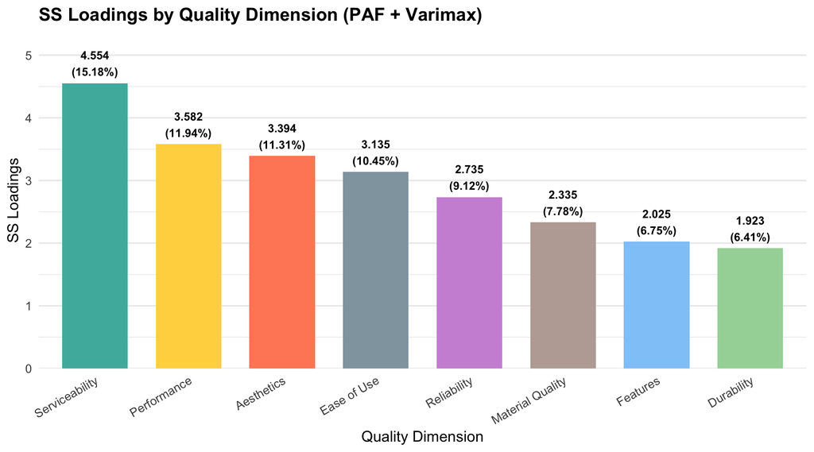

```r
# plot the previous table as a bar chart

dim_colours <- c("#4db6ac","#ffd54f","#ff8a65","#90a4ae",
                 "#ce93d8","#bcaaa4","#90caf9","#a5d6a7")

ggplot(eigen_final_df,
       aes(x = reorder(Factor, -SS_Load), y = SS_Load, fill = Factor)) +
  geom_col(width = 0.7, show.legend = FALSE) +
  geom_text(aes(label = paste0(SS_Load, "\n(", Var_Percentage, "%)")),
            vjust = -0.3, size = 3.2, fontface = "bold") +
  scale_fill_manual(values = setNames(dim_colours, factor_names)) +
  scale_y_continuous(expand = expansion(mult = c(0, 0.18))) +
  labs(title = "SS Loadings by Quality Dimension (PAF + Varimax)",
       x = "Quality Dimension", y = "SS Loadings") +
  theme_minimal(base_size = 12) +
  theme(plot.title = element_text(face = "bold"),
        axis.text.x = element_text(angle = 30, hjust = 1),
        panel.grid.major.x = element_blank())
```

Each factor’s SS loadings reflect how strongly and broadly that factor is defined by the quality items. A dimension with large SS loadings loads heavily on many items, meaning it captures a rich and well measured quality signal. Customers responses to those items move together consistently. In our case, that dimension would be Serviceability, which emerges as the most clearly and consistently measured construct across the item set. If it also turns out to be a significant predictor of repurchase intention, which will be explored in the next exercise. This suggests that a well-defined factor can also be commercially relevant when it significantly predicts repurchase intention . On the other hand, a factor with low SS loadings is tied to fewer or weaker item relationships, capturing a narrower quality signal. It may still predict repurchase intention in specific segments (for example, heavy users for whom Durability matters) but its overall explanatory power across the full sample will tend to be smaller, because the factor itself is less broadly represented in the data.

# 3 - Exercise 2: Oblique Factor Analysis (Promax)

## 3.1 - Oblique Factor Analysis

### 3.1.1 - Overall view

Given that quality dimensions are conceptually related, we expect factors to be correlated. Therefore, an oblique rotation (Promax) is expected to be appropriate. In this second exercice, an oblique factor analysis is run on the final 30-item set using Promax rotation, which allows factors to correlate and provides a more realistic representation of the quality structure.

```r
# perform an oblique factor analysis and print the results
fa_oblique <- fa(quality_data_final_ortho, nfactors = 8, fm = "pa",
                 rotate = "promax", scores = "regression")
print(fa_oblique, cut = 0.30, sort = TRUE)
```

```
## Factor Analysis using method =  pa
## Call: fa(r = quality_data_final_ortho, nfactors = 8, rotate = "promax",
##     scores = "regression", fm = "pa")
## Standardized loadings (pattern matrix) based upon correlation matrix
##      item   PA2   PA1   PA5   PA4   PA6   PA3   PA7   PA8   h2   u2 com
## qd24   21  0.95                                           0.88 0.12 1.0
## qd14   12  0.94                                           0.85 0.15 1.0
## qd10    8  0.91                                           0.85 0.15 1.0
## qd19   17  0.91                                           0.84 0.16 1.0
## qd21   19  0.85                                           0.78 0.22 1.0
## qd7     6        0.93                                     0.84 0.16 1.0
## qd1     1        0.91                                     0.81 0.19 1.0
## qd12   10        0.91                                     0.79 0.21 1.0
## qd5     4        0.75                                     0.72 0.28 1.0
## qd16   14        0.74                                     0.64 0.36 1.0
## qd2     2              0.96                               0.85 0.15 1.0
## qd20   18              0.91                               0.83 0.17 1.0
## qd27   24              0.87                               0.84 0.16 1.0
## qd9     7              0.86                               0.83 0.17 1.0
## qd3     3                    0.91                         0.77 0.23 1.0
## qd11    9                    0.90                         0.71 0.29 1.0
## qd13   11                    0.84                         0.80 0.20 1.0
## qd30   27                    0.74                         0.77 0.23 1.1
## qd15   13                          0.93                   0.86 0.14 1.0
## qd18   16                          0.91                   0.86 0.14 1.0
## qd32   29                          0.86                   0.83 0.17 1.0
## qd22   20                                0.93             0.86 0.14 1.0
## qd29   26                                0.89             0.83 0.17 1.0
## qd33   30                                0.86             0.75 0.25 1.0
## qd25   22                                      0.89       0.77 0.23 1.0
## qd6     5                                      0.87       0.83 0.17 1.0
## qd17   15                                      0.70       0.64 0.36 1.1
## qd28   25                                            0.82 0.68 0.32 1.0
## qd31   28                                            0.79 0.70 0.30 1.1
## qd26   23                                            0.73 0.65 0.35 1.0
##
##                        PA2  PA1  PA5  PA4  PA6  PA3  PA7  PA8
## SS loadings           4.23 3.85 3.39 2.99 2.57 2.49 2.19 1.97
## Proportion Var        0.14 0.13 0.11 0.10 0.09 0.08 0.07 0.07
## Cumulative Var        0.14 0.27 0.38 0.48 0.57 0.65 0.72 0.79
```

[output cut: 24 more lines]

```
## The total n.obs was  933  with Likelihood Chi Square =  510.78  with prob <  1.3e-24
##
## Tucker Lewis Index of factoring reliability =  0.98
## RMSEA index =  0.037  and the 90 % confidence intervals are  0.033 0.041
## BIC =  -1014.19
## Fit based upon off diagonal values = 1
## Measures of factor score adequacy
##                                                    PA2  PA1  PA5  PA4  PA6  PA3
## Correlation of (regression) scores with factors   0.98 0.97 0.98 0.97 0.97 0.97
## Multiple R square of scores with factors          0.97 0.95 0.96 0.93 0.95 0.94
## Minimum correlation of possible factor scores     0.93 0.90 0.91 0.86 0.89 0.87
##                                                    PA7  PA8
## Correlation of (regression) scores with factors   0.96 0.94
## Multiple R square of scores with factors          0.92 0.88
## Minimum correlation of possible factor scores     0.83 0.75
```

The pattern matrix, which displays the loadings, is very clean, with no cross-loadings at all. It has the same structure as the orthogonal solution. We now want to study the intercorrelation between factors, which can be done by analyzing the phi matrix.

### 3.1.2 - Phi matrix

```r
# Factor inter-correlations
phi_mat <- round(fa_oblique$Phi, 2)
rownames(phi_mat) <- colnames(phi_mat) <- factor_names

# show it as a table
as.data.frame(phi_mat) %>%
  kbl(caption = "Factor intercorrelation matrix (Phi): Promax Solution") %>%
  kable_styling(bootstrap_options = c("striped", "hover"), full_width = TRUE)
```

Factor intercorrelation matrix (Phi): Promax Solution

|  | Serviceability | Performance | Aesthetics | Ease of Use | Reliability | Material Quality | Features | Durability |
| --- | --- | --- | --- | --- | --- | --- | --- | --- |
| Serviceability | 1.00 | 0.56 | 0.54 | 0.52 | 0.54 | 0.40 | 0.54 | 0.49 |
| Performance | 0.56 | 1.00 | 0.66 | 0.64 | 0.60 | 0.57 | 0.69 | 0.63 |
| Aesthetics | 0.54 | 0.66 | 1.00 | 0.60 | 0.60 | 0.45 | 0.67 | 0.52 |
| Ease of Use | 0.52 | 0.64 | 0.60 | 1.00 | 0.60 | 0.47 | 0.59 | 0.54 |
| Reliability | 0.54 | 0.60 | 0.60 | 0.60 | 1.00 | 0.55 | 0.54 | 0.66 |
| Material Quality | 0.40 | 0.57 | 0.45 | 0.47 | 0.55 | 1.00 | 0.43 | 0.62 |
| Features | 0.54 | 0.69 | 0.67 | 0.59 | 0.54 | 0.43 | 1.00 | 0.49 |
| Durability | 0.49 | 0.63 | 0.52 | 0.54 | 0.66 | 0.62 | 0.49 | 1.00 |

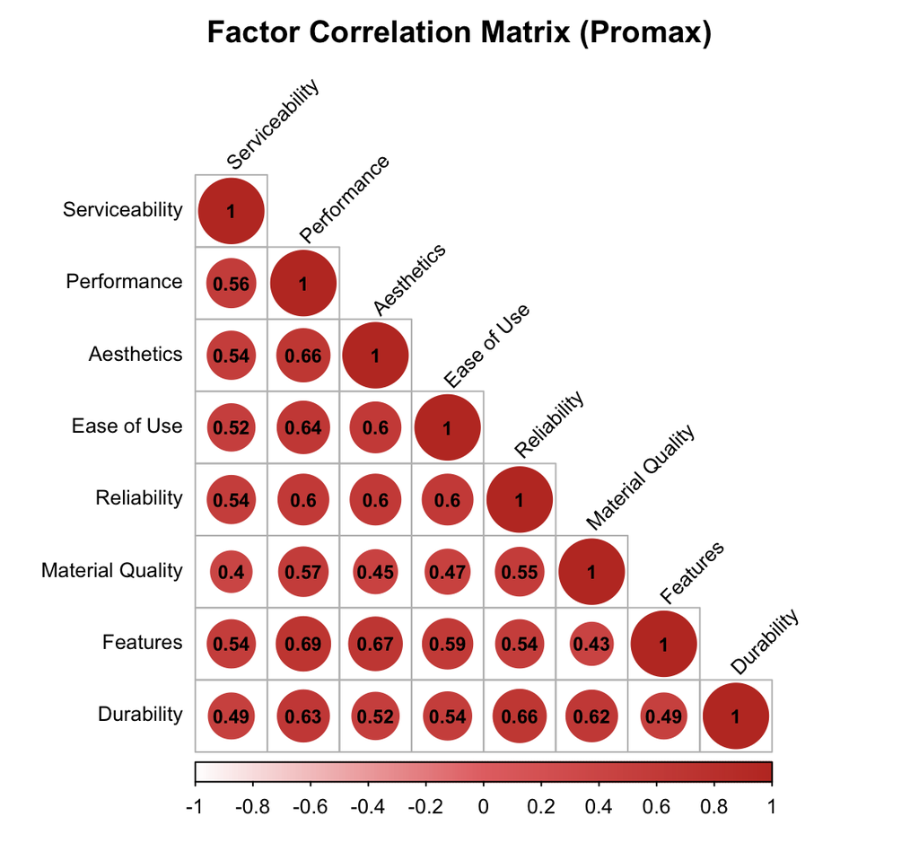

```r
# show it as a heatmap for better interpretation
corrplot(phi_mat,
         method   = "circle",
         type     = "lower",
         addCoef.col = "black",
         number.cex  = 0.75,
         tl.col   = "black",
         tl.srt   = 45,
         tl.cex   = 0.8,
         col      = colorRampPalette(c("white", "#e57373", "#c0392b"))(200),
         title    = "Factor Correlation Matrix (Promax)",
         mar      = c(0, 0, 2, 0),
         cl.lim   = c(0, 1))
```

All 8 factors are positively and moderately to strongly correlated, ranging from 0.40 (Serviceability with Material quality) to 0.69 (Performance with Features), which is the highest correlation. This means that Performance and Features share the most overlap (feature-rich phone tends to be perceived as higher performing overall). The fact that all correlations are above 0.3 validates the choice of oblique rotation: the quality dimensions are not independent in consumers minds. Varimax assumption of orthogonality would have been unrealistic. But correlations remain well below 0.85, so each dimension still retains its own identity.

### 3.1.3 - Factor scores and labels

After performing the analysis, we compute factor scores for the factors and name and label them appropriately. We print out the results for the 6 first respondents.

```r
# get the scores
factor_scores <- as.data.frame(fa_oblique$scores) %>%
  setNames(gsub(" ", "_", factor_names)) # converts to a data frame and renames the columns

# get the first 6 respondents
head(factor_scores) %>%
  kbl(digits = 3, caption = "Regression-based factor scores (first 6 respondents)") %>%
  kable_styling(bootstrap_options = c("striped", "hover"), full_width = TRUE)
```

Regression-based factor scores (first 6 respondents)

| Serviceability | Performance | Aesthetics | Ease_of_Use | Reliability | Material_Quality | Features | Durability |
| --- | --- | --- | --- | --- | --- | --- | --- |
| -1.097 | -0.575 | -1.437 | -0.710 | -1.113 | -1.043 | -0.865 | -0.265 |
| 0.140 | -0.196 | -0.113 | -0.630 | 0.050 | -1.050 | 0.306 | -0.851 |
| -1.100 | -0.548 | -1.440 | -0.847 | -1.108 | -0.200 | -0.931 | 0.148 |
| 0.336 | 1.072 | 1.214 | 0.964 | 0.944 | 1.167 | 1.314 | 0.900 |
| -1.071 | -0.510 | -0.172 | 0.497 | 0.087 | 0.004 | -0.954 | 0.279 |
| -1.097 | -0.470 | -1.471 | -1.371 | -0.747 | -0.031 | -0.891 | -0.533 |

By doing this, a respondent can now be described by 8 factor scores instead of their raw item responses. This is a compressed representation of where they stand on each latent dimension. These scores will now be used in further regression analysis.

## 3.2 - Regression Analysis

### 3.2.1 - Outcome variables: WTP and Repurchase Intention (RI)

As a next step, needed for the regression analysis, we compute mean scores for the three willingness to pay premium items (wtp1-wtp3) and the two repurchase intention items (ri1-ri2).

```r
# get the data from the start, and drop the NAs again
analysis_data <- data %>%
  select(all_of(c(paste0("qd", 1:33), "wtp1","wtp2","wtp3","ri1","ri2"))) %>%
  drop_na()

# calculate the mean of WTP and RI
outcomes <- analysis_data %>%
  transmute(
    WTP_mean = rowMeans(select(., wtp1, wtp2, wtp3), na.rm = TRUE),
    RI_mean  = rowMeans(select(., ri1, ri2),          na.rm = TRUE)
  )

summary(outcomes) %>%
  kbl(caption = "Descriptive statistics: WTP and RI mean scores") %>%
  kable_styling(bootstrap_options = c("striped", "hover"), full_width = FALSE)
```

Descriptive statistics: WTP and RI mean scores

|  | WTP_mean | RI_mean |
| --- | --- | --- |
|  | Min. :1.000 | Min. :1.00 |
|  | 1st Qu.:3.667 | 1st Qu.:4.50 |
|  | Median :4.667 | Median :5.50 |
|  | Mean :4.590 | Mean :5.35 |
|  | 3rd Qu.:5.667 | 3rd Qu.:6.50 |
|  | Max. :7.000 | Max. :7.00 |

```r
# combine the factor scores with the mean of wtp and ri
reg_data <- bind_cols(factor_scores, outcomes)
```

To test if the removed items in the factor analysis also have an important contribution to the regression analysis, we add them in another dataset below, which will also be tested.

```r
dropped_items <- quality_data_complete %>%
  select(qd4, qd8, qd23) %>%
  slice(1:nrow(factor_scores))

dropped_items_scaled <- dropped_items %>%
  mutate(across(everything(), scale)) %>%
  rename(qd4_scaled = qd4, qd8_scaled = qd8, qd23_scaled = qd23)

reg_data_extended <- bind_cols(reg_data, dropped_items_scaled)
```

In the next section, we run a regression analysis with the factor scores of the quality dimensions as independent and both the mean score of willingness to pay premium and repurchase intention as dependent variables.

### 3.2.2 - Regression Analysis: Willingness to Pay Premium (WTP)

Using the mean for WTP computed previously, we perform a linear regression fit with WTP as the dependent variable and the 8 factors as independent variables.

```r
# perform linear regression with WTP as the dependent variable (using the mean computed previously)
model_wtp <- lm(WTP_mean ~ Serviceability + Performance + Aesthetics + Ease_of_Use +
                            Material_Quality + Reliability + Features + Durability,
                data = reg_data)
summary(model_wtp)
```

```
##
## Call:
## lm(formula = WTP_mean ~ Serviceability + Performance + Aesthetics +
##     Ease_of_Use + Material_Quality + Reliability + Features +
##     Durability, data = reg_data)
##
## Residuals:
##     Min      1Q  Median      3Q     Max
## -4.6331 -0.7301  0.1154  0.8296  2.8440
##
## Coefficients:
##                  Estimate Std. Error t value Pr(>|t|)
## (Intercept)       4.58985    0.03740 122.715  < 2e-16 ***
## Serviceability    0.15080    0.05126   2.942  0.00334 **
## Performance       0.20280    0.07098   2.857  0.00437 **
## Aesthetics        0.07988    0.06150   1.299  0.19426
## Ease_of_Use       0.28969    0.05946   4.872  1.3e-06 ***
## Material_Quality -0.03113    0.05517  -0.564  0.57277
## Reliability       0.15751    0.06311   2.496  0.01274 *
## Features          0.19047    0.06492   2.934  0.00343 **
## Durability        0.04021    0.06911   0.582  0.56082
## ---
## Signif. codes:  0 '***' 0.001 '**' 0.01 '*' 0.05 '.' 0.1 ' ' 1
##
## Residual standard error: 1.142 on 924 degrees of freedom
## Multiple R-squared:  0.3737, Adjusted R-squared:  0.3682
## F-statistic:  68.9 on 8 and 924 DF,  p-value: < 2.2e-16
```

From the WTP regression, we get $R^2 = 0.374$, meaning that the quality dimensions explain about 37% of variance in willingness to pay premium. The significant factors are Ease of Use ($\beta = 0.290$, p < 0.001), Performance ($\beta = 0.203$, p < 0.01), Features ($\beta = 0.190$, p < 0.01), Serviceability ($\beta = 0.151$, p < 0.01), and Reliability ($\beta = 0.158$, p < 0.05). Non-significant factors are Material quality, Aesthetics and Durability.

Below, an additional regression is tested with the 3 items removed previously (qd4, qd8 and qd23).

```r
# same regression with additional items
model_wtp_ext <- lm(
  WTP_mean ~ Serviceability + Performance + Aesthetics + Ease_of_Use +
             Material_Quality + Reliability + Features + Durability +
             qd4_scaled + qd8_scaled + qd23_scaled,
  data = reg_data_extended
)
summary(model_wtp_ext)
```

```
##
## Call:
## lm(formula = WTP_mean ~ Serviceability + Performance + Aesthetics +
##     Ease_of_Use + Material_Quality + Reliability + Features +
##     Durability + qd4_scaled + qd8_scaled + qd23_scaled, data = reg_data_extended)
##
## Residuals:
##     Min      1Q  Median      3Q     Max
## -4.5487 -0.7140  0.1064  0.8225  2.7426
##
## Coefficients:
##                   Estimate Std. Error t value Pr(>|t|)
## (Intercept)       4.589854   0.036735 124.945  < 2e-16 ***
## Serviceability    0.155370   0.050391   3.083  0.00211 **
## Performance       0.201805   0.070624   2.857  0.00437 **
## Aesthetics        0.060135   0.060603   0.992  0.32132
## Ease_of_Use       0.294589   0.058660   5.022 6.14e-07 ***
## Material_Quality -0.003673   0.054496  -0.067  0.94628
## Reliability       0.126867   0.062195   2.040  0.04165 *
## Features          0.172963   0.073542   2.352  0.01889 *
## Durability        0.062101   0.068168   0.911  0.36254
## qd4_scaled        0.038772   0.037971   1.021  0.30749
## qd8_scaled       -0.039056   0.062749  -0.622  0.53383
## qd23_scaled       0.218308   0.038840   5.621 2.52e-08 ***
## ---
## Signif. codes:  0 '***' 0.001 '**' 0.01 '*' 0.05 '.' 0.1 ' ' 1
##
## Residual standard error: 1.122 on 921 degrees of freedom
## Multiple R-squared:  0.3978, Adjusted R-squared:  0.3906
## F-statistic:  55.3 on 11 and 921 DF,  p-value: < 2.2e-16
```

### 3.2.3 - Regression Analysis: Repurchase Intention (RI)

We repeat a similar analysis, but this time with RI as the dependent variable.

```r
# perform linear regression on the RI dependent variable
model_ri <- lm(RI_mean ~ Serviceability + Performance + Aesthetics + Ease_of_Use +
                          Material_Quality + Reliability + Features + Durability,
               data = reg_data)
summary(model_ri)
```

```
##
## Call:
## lm(formula = RI_mean ~ Serviceability + Performance + Aesthetics +
##     Ease_of_Use + Material_Quality + Reliability + Features +
##     Durability, data = reg_data)
##
## Residuals:
##     Min      1Q  Median      3Q     Max
## -4.3343 -0.6376  0.1726  0.7127  3.3052
##
## Coefficients:
##                  Estimate Std. Error t value Pr(>|t|)
## (Intercept)       5.34995    0.03485 153.526  < 2e-16 ***
## Serviceability    0.11393    0.04776   2.386   0.0173 *
## Performance       0.34742    0.06613   5.254 1.85e-07 ***
## Aesthetics        0.06118    0.05729   1.068   0.2858
## Ease_of_Use       0.31445    0.05540   5.676 1.84e-08 ***
## Material_Quality  0.03309    0.05140   0.644   0.5199
## Reliability       0.05400    0.05880   0.918   0.3587
## Features          0.07430    0.06048   1.229   0.2196
## Durability        0.14668    0.06439   2.278   0.0230 *
## ---
## Signif. codes:  0 '***' 0.001 '**' 0.01 '*' 0.05 '.' 0.1 ' ' 1
##
## Residual standard error: 1.064 on 924 degrees of freedom
## Multiple R-squared:  0.4353, Adjusted R-squared:  0.4305
## F-statistic: 89.05 on 8 and 924 DF,  p-value: < 2.2e-16
```

From the above results, we have $R^2 = 0.435$, meaning the 8 quality dimensions together explain 43.5% of the variance in repurchase intention, higher than for WTP. This is solid result for a consumer behavior regression, and the F-test confirms the model is highly significant overall.

The most significant predictors are Performance ($\beta = 0.347$, p < 0.001), Ease of Use ($\beta = 0.314$, p < 0.001), Durability ($\beta = 0.147$, p < 0.05), and Serviceability ($\beta = 0.114$, p < 0.05). The non-significant factors are Reliability, Aesthetics, Material Quality, and Features.

From a managerial interpretation, this means that Performance and Ease of Use are the strongest drivers for RI. A smartphone that performs its core functions well and is easy to use is strongly associated with repurchase intention. Durability and Serviceability are secondary but still important: customers care that the phone lasts and that support is available when needed. On the other hand, Aesthetics, Features, and Reliability do not significantly predict repurchase.

Comparing it with the WTP regression, the difference is Durability and Features. Durability matters for repurchase but not for WTP. On the other hand, the Features factor drives WTP but not RI. Customers will pay more for an innovative, feature-rich phone, but features alone don’t make them come back. What brings them back is whether it lasts. Reliability follows a similar pattern, significant for WTP but not RI.

As before, an additional regression is tested with the 3 items qd4, qd8 and qd23.

```r
# same regression with additional items
model_ri_ext <- lm(
  RI_mean ~ Serviceability + Performance + Aesthetics + Ease_of_Use +
            Material_Quality + Reliability + Features + Durability +
            qd4_scaled + qd8_scaled + qd23_scaled,
  data = reg_data_extended
)
summary(model_ri_ext)
```

```
##
## Call:
## lm(formula = RI_mean ~ Serviceability + Performance + Aesthetics +
##     Ease_of_Use + Material_Quality + Reliability + Features +
##     Durability + qd4_scaled + qd8_scaled + qd23_scaled, data = reg_data_extended)
##
## Residuals:
##     Min      1Q  Median      3Q     Max
## -4.3084 -0.6058  0.1491  0.7026  3.3633
##
## Coefficients:
##                  Estimate Std. Error t value Pr(>|t|)
## (Intercept)       5.34995    0.03460 154.617  < 2e-16 ***
## Serviceability    0.11611    0.04746   2.446  0.01462 *
## Performance       0.35422    0.06652   5.325 1.27e-07 ***
## Aesthetics        0.05074    0.05708   0.889  0.37426
## Ease_of_Use       0.32553    0.05525   5.892 5.36e-09 ***
## Material_Quality  0.05215    0.05133   1.016  0.30990
## Reliability       0.03600    0.05858   0.614  0.53908
## Features          0.09529    0.06927   1.376  0.16926
## Durability        0.16671    0.06421   2.596  0.00957 **
## qd4_scaled        0.06907    0.03577   1.931  0.05377 .
## qd8_scaled       -0.07184    0.05910  -1.216  0.22449
## qd23_scaled       0.10236    0.03658   2.798  0.00525 **
## ---
## Signif. codes:  0 '***' 0.001 '**' 0.01 '*' 0.05 '.' 0.1 ' ' 1
##
## Residual standard error: 1.057 on 921 degrees of freedom
## Multiple R-squared:  0.4451, Adjusted R-squared:  0.4385
## F-statistic: 67.16 on 11 and 921 DF,  p-value: < 2.2e-16
```

For both the WTP and RI regressions, the $R^2$ is only slightly better. Therefore, to keep a consistent and simpler model, we keep the regression with the 8 factors onyl as the main solution for the rest of this work.

### 3.2.4 - Coefficient comparison plot

A summary of the above findings can be viewed in the plot below, which compares the coefficients of both regressions against each other.

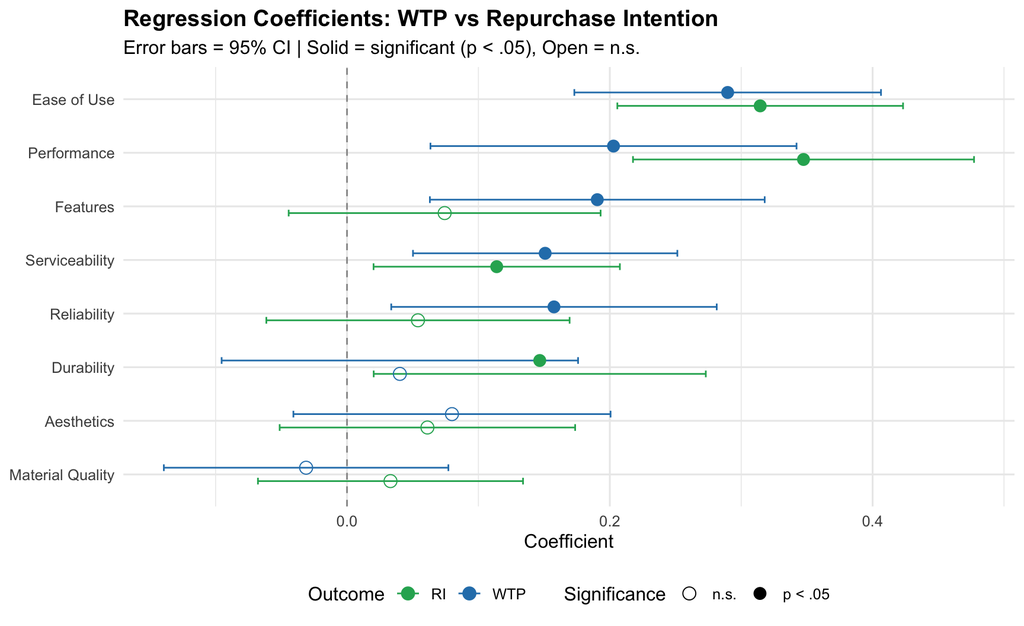

```r
# combine regression results from both models into one data frame
# tidy() extracts coefficients, std errors, p-values, and CI bounds
coef_all <- bind_rows(
  tidy(model_wtp, conf.int = TRUE) %>% mutate(Outcome = "WTP"),
  tidy(model_ri,  conf.int = TRUE) %>% mutate(Outcome = "RI")
) %>%
  filter(term != "(Intercept)") %>%       # drop intercept
  mutate(term = gsub("_", " ", term), sig = p.value < 0.05)

# plot coefficients with 95% CI error bars, side by side for WTP and RI
# solid point = significant (p < .05), open circle = not significant
ggplot(coef_all, aes(x = reorder(term, estimate), y = estimate, colour = Outcome)) +
  geom_hline(yintercept = 0, linetype = "dashed", colour = "grey60") +
  geom_errorbar(aes(ymin = conf.low, ymax = conf.high), width = 0.25,
                position = position_dodge(0.5)) +
  geom_point(aes(shape = sig), size = 3.5, position = position_dodge(0.5)) +
  scale_colour_manual(values = c("WTP" = "#2980b9", "RI" = "#27ae60")) +
  scale_shape_manual(values = c("TRUE" = 16, "FALSE" = 1),
                     labels = c("TRUE" = "p < .05", "FALSE" = "n.s.")) +
  coord_flip() +
  labs(title = "Regression Coefficients: WTP vs Repurchase Intention",
       subtitle = "Error bars = 95% CI | Solid = significant (p < .05), Open = n.s.",
       x = NULL, y = "Coefficient", colour = "Outcome", shape = "Significance") +
  theme_minimal(base_size = 12) +
  theme(plot.title = element_text(face = "bold"), legend.position = "bottom")
```

**Interpretation:**

- For WTP (R2 approx. 0.37), the significant positive predictors are Performance, Ease of Use, Serviceability, Reliability, and Features. Ease of Use has the strongest effect: Customers who find the phone intuitive are most willing to pay above the market price.
- For RI (R2 approx. 0.44), the significant positive predictors are Performance, Ease of Use, Serviceability, and Durability. Performance and Ease of Use are the strongest drivers. As discussed above, Durability uniquely predicts repeat purchase but not WTP. Serviceability is a significant predictor in both models, highlighting that after-sale support is commercially as important as the product itself.

The results are also summarized below, with each of the eight quality dimensions linked to the established marketing literature.

```r
data.frame(
  Dimension          = factor_names,
  Literature_Anchor  = c(
    "Serviceability (Garvin 1988)", "Performance (Garvin 1988)",
    "Aesthetics (Garvin 1988)",     "Ease of Use (Brucks et al. 2000)",
    "Reliability (Garvin 1988)",      "Conformance / Materials",
    "Features (Garvin 1988)",       "Durability (Garvin 1988)"
  ),
  WTP_Driver = c("Yes *","Yes *","No","Yes **","Yes *","No","Yes *","No"),
  RI_Driver  = c("Yes *","Yes **","No","Yes **","No","No","No","Yes *"),
  stringsAsFactors = FALSE
) %>%
  kbl(col.names = c("Quality Dimension","Literature Anchor","WTP Driver","RI Driver"),
      caption = "Quality Dimensions as Drivers of WTP and Repurchase Intention") %>%
  kable_styling(bootstrap_options = c("striped","hover"), full_width = TRUE) %>%
  column_spec(1, bold = TRUE) %>%
  footnote(general = "** = strongest predictor | * = significant (p < .05) | No = not significant")
```

Quality Dimensions as Drivers of WTP and Repurchase Intention

| Quality Dimension | Literature Anchor | WTP Driver | RI Driver |
| --- | --- | --- | --- |
| Serviceability | Serviceability (Garvin 1988) | Yes * | Yes * |
| Performance | Performance (Garvin 1988) | Yes * | Yes ** |
| Aesthetics | Aesthetics (Garvin 1988) | No | No |
| Ease of Use | Ease of Use (Brucks et al. 2000) | Yes ** | Yes ** |
| Reliability | Reliability (Garvin 1988) | Yes * | No |
| Material Quality | Conformance / Materials | No | No |
| Features | Features (Garvin 1988) | Yes * | No |
| Durability | Durability (Garvin 1988) | No | Yes * |

Note:  
** = strongest predictor | * = significant (p < .05) | No = not significant

## 3.3 - Brand-Level Analysis

### 3.3.1 - Sample by brand

In the previous sections, we did not take into account the different brands when doing the analysis. Now, we want to see if the results of the regression analysis for RI differ across brands, especially for Samsung vs Apple vs LG. We start by selecting the brand variables for our analysis.

```r
# select data again including brand variable, drop NAs
# and convert numeric brand codes to labelled factor
analysis_data_brand <- data %>%
  select(all_of(c(paste0("qd", 1:33),
                  "wtp1","wtp2","wtp3","ri1","ri2","brandrec"))) %>%
  drop_na() %>%
  mutate(Brand = factor(brandrec, levels = 1:5,
                        labels = c("Apple","Samsung","LG","Motorola","Others")))

# display sample size and percentage per brand
table(analysis_data_brand$Brand) %>%
  as.data.frame() %>%
  setNames(c("Brand","N")) %>%
  mutate(Percentage = round(N / sum(N) * 100, 1)) %>%
  kbl(caption = "Sample size by brand") %>%
  kable_styling(bootstrap_options = c("striped","hover"), full_width = FALSE)
```

Sample size by brand

| Brand | N | Percentage |
| --- | --- | --- |
| Apple | 514 | 55.1 |
| Samsung | 228 | 24.4 |
| LG | 63 | 6.8 |
| Motorola | 68 | 7.3 |
| Others | 60 | 6.4 |

Apple brand makes up 55% of the data, followed by Samsung with approx. 24%. Only 7% of the data concerns LG.

### 3.3.2 - Factor scores by brand

To examine whether perceived quality dimensions differ across smartphone brands, the oblique 8 factor solution is calculated again on the brand labelled subsample. Factor scores are extracted for each respondent, along with their mean WTP and RI scores. Mean factor scores are then computed per brand, providing a standardised profile of how each brand is perceived across the eight quality dimensions. Since factor scores are standardised, values above 0 indicate above-average perception and values below 0 indicate below-average perception relative to the overall sample.

```r
# Select only the 30 retained quality items from the brand dataset
final_items_brand <- analysis_data_brand %>%
  select(all_of(names(quality_data_final_ortho)))

# Run oblique PAF again on the brand subset to get brand-specific factor scores
fa_oblique_brand <- fa(final_items_brand, nfactors = 8, fm = "pa",
                       rotate = "promax", scores = "regression")

# Extract factor scores and rename columns to match factor names
factor_scores_brand <- as.data.frame(fa_oblique_brand$scores) %>%
  setNames(gsub(" ", "_", factor_names))

# Compute outcome means (WTP and RI) and retain brand label per respondent
outcomes_brand <- analysis_data_brand %>%
  transmute(
    Brand    = Brand,
    WTP_mean = rowMeans(select(., wtp1, wtp2, wtp3), na.rm = TRUE),
    RI_mean  = rowMeans(select(., ri1, ri2),          na.rm = TRUE)
  )

# Combine factor scores, outcomes and brand into one regression dataset
reg_data_brand <- bind_cols(factor_scores_brand, outcomes_brand)
```

```r
# Compute mean factor score for each of the 8 factors, grouped by brand
brand_means <- reg_data_brand %>%
  group_by(Brand) %>%
  summarise(across(Serviceability:Durability, ~ round(mean(.), 2)), .groups = "drop")

# display the table
brand_means %>%
  kbl(caption = "Mean factor scores by brand (standardised)") %>%
  kable_styling(bootstrap_options = c("striped","hover"), full_width = TRUE) %>%
  column_spec(1, bold = TRUE)
```

Mean factor scores by brand (standardised)

| Brand | Serviceability | Performance | Aesthetics | Ease_of_Use | Reliability | Material_Quality | Features | Durability |
| --- | --- | --- | --- | --- | --- | --- | --- | --- |
| Apple | 0.17 | 0.20 | 0.15 | 0.16 | 0.15 | 0.09 | 0.19 | 0.13 |
| Samsung | -0.13 | -0.12 | -0.07 | -0.11 | -0.14 | 0.01 | -0.07 | -0.10 |
| LG | -0.31 | -0.30 | -0.22 | -0.22 | -0.19 | -0.20 | -0.32 | -0.14 |
| Motorola | -0.10 | -0.25 | -0.24 | -0.36 | -0.11 | -0.22 | -0.40 | -0.13 |
| Others | -0.56 | -0.67 | -0.48 | -0.34 | -0.44 | -0.37 | -0.59 | -0.43 |

### 3.3.3 - Brand comparison

To visualise differences in quality perceptions across the 3 brands of interest, mean standardised factor scores are plotted side by side for Apple, Samsung and LG. Each bar represents a brands average score on a given quality dimension relative to the overall sample mean. Bar to the right of zero indicate above-average perception, bars to the left indicate below-average. This allows for a direct comparison of each brands perceived strengths and weaknesses across the eight quality dimensions.

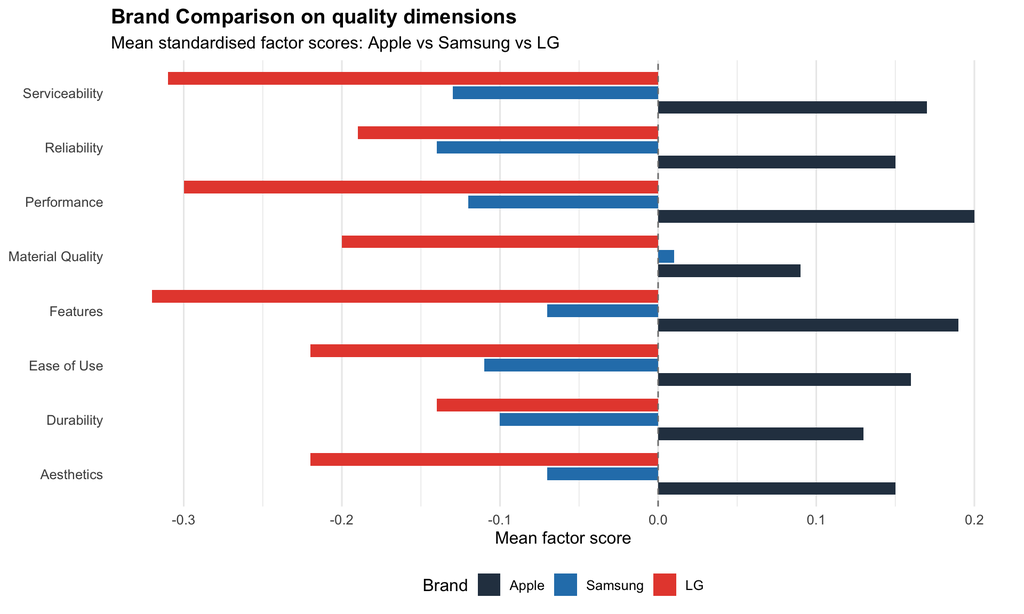

```r
# filter to the three main brands and reshape to long format for plotting
brand_long <- brand_means %>%
  filter(Brand %in% c("Apple","Samsung","LG")) %>%
  pivot_longer(-Brand, names_to = "Dimension", values_to = "Score") %>%
  mutate(Dimension = gsub("_"," ", Dimension))

# Plot bar chart
ggplot(brand_long, aes(x = Dimension, y = Score, fill = Brand)) +
  geom_col(position = position_dodge(0.8), width = 0.7) +
  geom_hline(yintercept = 0, linetype = "dashed", colour = "grey50") +
  scale_fill_manual(values = c("Apple"="#2c3e50","Samsung"="#2980b9","LG"="#e74c3c")) +
  coord_flip() +
  labs(title = "Brand Comparison on quality dimensions",
       subtitle = "Mean standardised factor scores: Apple vs Samsung vs LG",
       x = NULL, y = "Mean factor score") +
  theme_minimal(base_size = 12) +
  theme(plot.title = element_text(face = "bold"), legend.position = "bottom",
        panel.grid.major.y = element_blank())
```

Looking at the obtained bar chart, Apple consistently scores above the sample average across all eight quality dimensions, with particularly strong scores on Performance and Features. Samsung scores close to zero across most dimensions, suggesting average perceptions overall, with a slight positive value for Material Quality. LG scores below the sample average on every single dimension. The largest gaps can be found on Serviceability, Features, and Performance. In short, Apple is perceived as the strongest brand across all quality dimensions in this sample, Samsung is middling, and LG consistently underperforms relative to the average respondent’s perceptions.

### 3.3.4 - Factor score distributions by brand

While mean factor scores summarise global tendency, the boxplots below show the full distribution of individual scores per brand and dimension.

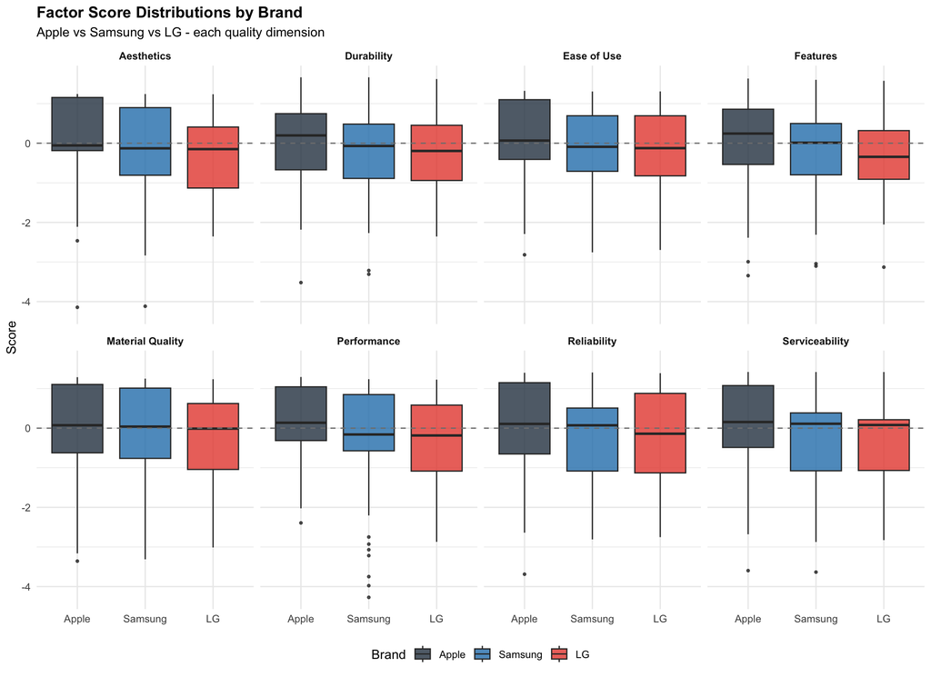

```r
# Filter to main three brands, reshape to long format
reg_data_brand %>%
  filter(Brand %in% c("Apple","Samsung","LG")) %>%
  pivot_longer(Serviceability:Durability,
               names_to = "Dimension", values_to = "Score") %>%
  mutate(Dimension = gsub("_"," ", Dimension)) %>%
      # Boxplot per dimension,
  ggplot(aes(x = Brand, y = Score, fill = Brand)) +
  geom_boxplot(alpha = 0.8, outlier.size = 0.8) +
  geom_hline(yintercept = 0, linetype = "dashed", colour = "grey50") +
  facet_wrap(~ Dimension, nrow = 2) +
  scale_fill_manual(values = c("Apple"="#2c3e50","Samsung"="#2980b9","LG"="#e74c3c")) +
  labs(title = "Factor Score Distributions by Brand",
       subtitle = "Apple vs Samsung vs LG - each quality dimension",
       x = NULL, y = "Score") +
  theme_minimal(base_size = 11) +
  theme(plot.title = element_text(face = "bold"), legend.position = "bottom",
        strip.text = element_text(face = "bold"))
```

### 3.3.5 - Brand-specific regression: Repurchase Intention

To examine whether the drivers of RI differ across brands, separate linear regressions are estimated for Apple, Samsung and LG.

```r
brand_list <- c("Apple","Samsung","LG")

# Fit a separate OLS regression for each brand with RI mean as the dependent variable
ri_models <- setNames(lapply(brand_list, function(br) {
  df <- reg_data_brand %>% filter(Brand == br)
  lm(RI_mean ~ Serviceability + Performance + Aesthetics + Ease_of_Use +
               Material_Quality + Reliability + Features + Durability, data = df)
}), brand_list)

# print regression summary for each brand with sample size
for (br in brand_list) {
  n_br <- nrow(reg_data_brand %>% filter(Brand == br))
  cat("\n--- Brand:", br, " (n =", n_br, ") ---\n")
  print(summary(ri_models[[br]]))
}
```

```
##
## --- Brand: Apple  (n = 514 ) ---
##
## Call:
## lm(formula = RI_mean ~ Serviceability + Performance + Aesthetics +
##     Ease_of_Use + Material_Quality + Reliability + Features +
##     Durability, data = df)
##
## Residuals:
##     Min      1Q  Median      3Q     Max
## -3.4210 -0.4582  0.1169  0.5396  2.4794
##
## Coefficients:
##                  Estimate Std. Error t value Pr(>|t|)
## (Intercept)       5.72283    0.04026 142.138  < 2e-16 ***
## Serviceability    0.16510    0.05594   2.951  0.00331 **
## Performance       0.21304    0.08192   2.600  0.00959 **
## Aesthetics        0.12662    0.06621   1.912  0.05640 .
## Ease_of_Use       0.28782    0.06358   4.527 7.47e-06 ***
## Material_Quality  0.00814    0.05695   0.143  0.88640
## Reliability       0.08106    0.06807   1.191  0.23428
## Features         -0.01222    0.06799  -0.180  0.85741
## Durability        0.08489    0.07307   1.162  0.24585
## ---
## Signif. codes:  0 '***' 0.001 '**' 0.01 '*' 0.05 '.' 0.1 ' ' 1
##
## Residual standard error: 0.8809 on 505 degrees of freedom
## Multiple R-squared:  0.3917, Adjusted R-squared:  0.3821
## F-statistic: 40.65 on 8 and 505 DF,  p-value: < 2.2e-16
##
##
## --- Brand: Samsung  (n = 228 ) ---
##
## Call:
## lm(formula = RI_mean ~ Serviceability + Performance + Aesthetics +
##     Ease_of_Use + Material_Quality + Reliability + Features +
##     Durability, data = df)
##
## Residuals:
##     Min      1Q  Median      3Q     Max
```

[output cut: 34 more lines]

```
## (Intercept)       4.73286    0.15733  30.083   <2e-16 ***
## Serviceability   -0.11788    0.19090  -0.617   0.5395
## Performance       0.40656    0.27581   1.474   0.1463
## Aesthetics       -0.07559    0.22357  -0.338   0.7366
## Ease_of_Use       0.05864    0.21117   0.278   0.7823
## Material_Quality  0.48146    0.19064   2.525   0.0145 *
## Reliability       0.05485    0.23003   0.238   0.8124
## Features          0.26185    0.27431   0.955   0.3440
## Durability       -0.10471    0.23467  -0.446   0.6572
## ---
## Signif. codes:  0 '***' 0.001 '**' 0.01 '*' 0.05 '.' 0.1 ' ' 1
##
## Residual standard error: 1.147 on 54 degrees of freedom
## Multiple R-squared:  0.4062, Adjusted R-squared:  0.3182
## F-statistic: 4.617 on 8 and 54 DF,  p-value: 0.0002471
```

### 3.3.6 - RI coefficient comparison: Apple vs Samsung vs LG

The table below summarises the three brand-specific regression results into a single comparison table.

```r
# helper function to convert p-values to significance stars
sig_stars <- function(p) {
  case_when(p < .001 ~ "***", p < .01 ~ "**", p < .05 ~ "*",
            p < .10  ~ "t",   TRUE    ~ "")
}

# extract coefficients and significance stars for each brand into separate tables
ri_tabs <- lapply(brand_list, function(br) {
  tidy(ri_models[[br]]) %>%
    filter(term != "(Intercept)") %>%
    transmute(
      Dimension              = gsub("_"," ", term),
      !!paste0(br,"_b")    := round(estimate, 3),
      !!paste0(br,"_sig")  := sig_stars(p.value)
    )
})

# Join all three brand tables for better comparison
ri_tabs[[1]] %>%
  left_join(ri_tabs[[2]], by = "Dimension") %>%
  left_join(ri_tabs[[3]], by = "Dimension") %>%
  kbl(caption = "RI Regression Coefficients by Brand",
      align = "lcccccc") %>%
  kable_styling(bootstrap_options = c("striped","hover"), full_width = TRUE) %>%
  column_spec(1, bold = TRUE) %>%
  footnote(general = "t p<.10 | * p<.05 | ** p<.01 | *** p<.001")
```

RI Regression Coefficients by Brand

Dimension

Apple_b

Apple_sig

Samsung_b

Samsung_sig

LG_b

LG_sig

Serviceability

0.165

0.051

-0.118

Performance

0.213

0.293

0.407

Aesthetics

0.127

t

0.008

-0.076

Ease of Use

0.288

***

0.261

0.059

Material Quality

0.008

-0.050

0.481

Reliability

0.081

0.111

0.055

Features

-0.012

-0.029

0.262

Durability

0.085

0.420

-0.105

Note:

t p<.10 | * p<.05 | ** p<.01 | *** p<.001

**Interpretation of brand differences:**

**Apple:** Serviceability, Performance, and Ease of Use drive RI, consistent with Apple’s positioning around seamless user experience and premium support.

**Samsung:** Performance, Ease of Use, and Durability drive RI. Samsung customers stay loyal because the phone performs reliably, is easy to use, and lasts, with Durability being the strongest predictor.

**LG:** Material Quality is the primary driver of repurchase intention. LG scores below average on Serviceability, which may limit its ability to convert satisfaction into repeat purchase. Results should be interpreted with caution given the smaller LG subsample.

### 3.3.7 - Points of parity and points of difference summary

To identify competitive positioning across brands, we combine both previously obtained results in a table below. Each quality dimension is classified based on whether it significantly predicts RI (p < .05) for each brand, combined with whether the brand scores above or below the cross-brand average on that dimension.

```r
# Helper: extract RI significance per brand (p < .05 threshold)
get_sig <- function(model, brand) {
  tidy(model) %>%
    filter(term != "(Intercept)") %>%
    transmute(
      Dimension = gsub("_", " ", term),
      !!paste0(brand, "_RI_sig") := ifelse(p.value < .05, "Sig.*", "—")
    )
}

# Extract significance for each brand
ri_sig_apple   <- get_sig(ri_models[["Apple"]],   "Apple")
ri_sig_samsung <- get_sig(ri_models[["Samsung"]], "Samsung")
ri_sig_lg      <- get_sig(ri_models[["LG"]],      "LG")

# Mean score direction per brand (above/below 0 = above/below cross-brand mean)
mean_direction <- brand_means %>%
  filter(Brand %in% c("Apple","Samsung","LG")) %>%
  pivot_longer(-Brand, names_to = "Dimension", values_to = "Score") %>%
  mutate(Dimension = gsub("_"," ", Dimension),
         Direction = case_when(Score >  0.05 ~ "Above avg.",
                               Score < -0.05 ~ "Below avg.",
                               TRUE          ~ "Near avg.")) %>%
  select(Brand, Dimension, Direction) %>%
  pivot_wider(names_from = Brand, values_from = Direction,
              names_glue = "{Brand}_Score")

# Join significance and score direction, then classify each dimension per brand:
# PoP = significant for both Apple and Samsung (shared driver)
# Apple/Samsung Advantage = significant for one brand only
# LG Differentiator = only significant for LG
pop_pod <- ri_sig_apple %>%
  left_join(ri_sig_samsung, by = "Dimension") %>%
  left_join(ri_sig_lg,      by = "Dimension") %>%
  left_join(mean_direction,  by = "Dimension") %>%
  mutate(
    Classification = case_when(
      Apple_RI_sig == "Sig.*" & Samsung_RI_sig == "Sig.*" ~ "Point of Parity (RI)",
      Apple_RI_sig == "Sig.*" & Samsung_RI_sig == "—"     ~ "Apple Advantage",
      Apple_RI_sig == "—"     & Samsung_RI_sig == "Sig.*" ~ "Samsung Advantage",
      LG_RI_sig    == "Sig.*"                             ~ "LG Differentiator",
      TRUE                                                ~ "Not significant"
    )
  ) %>%
  select(Dimension, Apple_Score, Samsung_Score, LG_Score,
         Apple_RI_sig, Samsung_RI_sig, LG_RI_sig, Classification)
# show table
pop_pod %>%
  kbl(
    col.names = c("Dimension",
                  "Apple Score", "Samsung Score", "LG Score",
                  "Apple RI*", "Samsung RI*", "LG RI*",
                  "Classification"),
    caption = "Points of Parity and Difference: Mean Factor Scores + RI Regression Significance"
  ) %>%
  kable_styling(bootstrap_options = c("striped","hover"), full_width = TRUE) %>%
  column_spec(1, bold = TRUE) %>%
  column_spec(8, bold = TRUE,
              color = case_when(
                pop_pod$Classification == "Point of Parity (RI)" ~ "#2980b9",
                pop_pod$Classification == "Apple Advantage"      ~ "#27ae60",
                pop_pod$Classification == "Samsung Advantage"    ~ "#e67e22",
                pop_pod$Classification == "LG Differentiator"    ~ "#c0392b",
                TRUE                                             ~ "grey50"
              )) %>%
  footnote(general = "Score direction: Above/Below/Near the cross-brand mean. RI* = significant RI predictor (p < .05)")
```

Points of Parity and Difference: Mean Factor Scores + RI Regression Significance

| Dimension | Apple Score | Samsung Score | LG Score | Apple RI* | Samsung RI* | LG RI* | Classification |
| --- | --- | --- | --- | --- | --- | --- | --- |
| Serviceability | Above avg. | Below avg. | Below avg. | Sig.* | — | — | Apple Advantage |
| Performance | Above avg. | Below avg. | Below avg. | Sig.* | Sig.* | — | Point of Parity (RI) |
| Aesthetics | Above avg. | Below avg. | Below avg. | — | — | — | Not significant |
| Ease of Use | Above avg. | Below avg. | Below avg. | Sig.* | Sig.* | — | Point of Parity (RI) |
| Material Quality | Above avg. | Near avg. | Below avg. | — | — | Sig.* | LG Differentiator |
| Reliability | Above avg. | Below avg. | Below avg. | — | — | — | Not significant |
| Features | Above avg. | Below avg. | Below avg. | — | — | — | Not significant |
| Durability | Above avg. | Below avg. | Below avg. | — | Sig.* | — | Samsung Advantage |

Note:  
Score direction: Above/Below/Near the cross-brand mean. RI* = significant RI predictor (p < .05)

Dimensions significant for both Apple and Samsung are classified as points of parity. Dimensions significant for only one brand represent that brand’s competitive advantage. LG differentiators are dimensions uniquely driving LG’s repurchase intention.

# Appendix

## Declaration on the Use of Generative AI Tools

AI tools were used during the preparation of this report to improve workflow efficiency, particularly for coding support and for formatting tables, graphics, and results in the HTML output. Claude was consulted to assist with technical implementation and visual presentation.

The analysis itself, including the choice of methods, interpretation of findings, and final conclusions, was carried out independently by the authors.